# Hotel 1 EDA

Caitlin Howansky & Wei Li

October 14, 2019

```r
# load the data files
hot1 <- read_csv('BOOKINGS_ATLCP.csv')
hot2 <- read_csv('BOOKINGS_NYCHA.csv')
```

##**EDA**

##**Data Overview**

```r
#first look at all tables
head(hot1)
```

```
## # A tibble: 6 x 21
##   product_type stay_dt   dow booking_dt days_prior daily_gross_boo~
##   <chr>        <chr>   <dbl> <chr>           <dbl>            <dbl>
## 1 BUSINESS TR~ 02/01/~     4 02/01/2012          0                1
## 2 BUSINESS TR~ 02/01/~     4 01/31/2012          1                0
## 3 BUSINESS TR~ 02/01/~     4 01/30/2012          2                7
## 4 BUSINESS TR~ 02/01/~     4 01/29/2012          3                0
## 5 BUSINESS TR~ 02/01/~     4 01/28/2012          4                0
## 6 BUSINESS TR~ 02/01/~     4 01/27/2012          5                2
## # ... with 15 more variables: daily_gross_rev <dbl>,
## #   daily_cxl_bookings <dbl>, daily_cxl_rev <dbl>,
## #   daily_net_bookings <dbl>, daily_net_rev <dbl>,
## #   cummulative_gross_bookings <dbl>, cummulative_gross_rev <dbl>,
## #   cummulative_cxl_bookings <dbl>, cummulative_cxl_rev <dbl>, OTB <dbl>,
## #   OTB_rev <dbl>, OTB_to_be_cxl <dbl>, OTB_rev_to_be_cxl <dbl>,
## #   OTB_to_survive <dbl>, OTB_rev_to_survive <dbl>
```

```r
head(hot2)
```

```
## # A tibble: 6 x 21
##   product_type stay_dt   dow booking_dt days_prior daily_gross_boo~
##   <chr>        <chr>   <dbl> <chr>           <dbl>            <dbl>
## 1 BUSINESS TR~ 02/01/~     4 02/01/2012          0                2
## 2 BUSINESS TR~ 02/01/~     4 01/31/2012          1                4
## 3 BUSINESS TR~ 02/01/~     4 01/30/2012          2                6
## 4 BUSINESS TR~ 02/01/~     4 01/29/2012          3                0
## 5 BUSINESS TR~ 02/01/~     4 01/28/2012          4                3
## 6 BUSINESS TR~ 02/01/~     4 01/27/2012          5               10
## # ... with 15 more variables: daily_gross_rev <dbl>,
## #   daily_cxl_bookings <dbl>, daily_cxl_rev <dbl>,
## #   daily_net_bookings <dbl>, daily_net_rev <dbl>,
## #   cummulative_gross_bookings <dbl>, cummulative_gross_rev <dbl>,
## #   cummulative_cxl_bookings <dbl>, cummulative_cxl_rev <dbl>, OTB <dbl>,
## #   OTB_rev <dbl>, OTB_to_be_cxl <dbl>, OTB_rev_to_be_cxl <dbl>,
## #   OTB_to_survive <dbl>, OTB_rev_to_survive <dbl>
```

```r
#summaries of data
summary(hot1)
```

```
##  product_type         stay_dt               dow         booking_dt
##  Length:46299       Length:46299       Min.   :1.000   Length:46299
##  Class :character   Class :character   1st Qu.:2.000   Class :character
##  Mode  :character   Mode  :character   Median :4.000   Mode  :character
##                                        Mean   :4.041
##                                        3rd Qu.:6.000
##                                        Max.   :7.000
##    days_prior daily_gross_bookings daily_gross_rev   daily_cxl_bookings
##  Min.   : 0   Min.   :  0.0        Min.   :    0.0   Min.   : 0.0000
##  1st Qu.:15   1st Qu.:  0.0        1st Qu.:    0.0   1st Qu.: 0.0000
##  Median :30   Median :  0.0        Median :    0.0   Median : 0.0000
##  Mean   :30   Mean   :  1.1        Mean   :  127.1   Mean   : 0.1736
##  3rd Qu.:45   3rd Qu.:  0.0        3rd Qu.:    0.0   3rd Qu.: 0.0000
##  Max.   :60   Max.   :528.0        Max.   :67106.0   Max.   :98.0000
##  daily_cxl_rev     daily_net_bookings daily_net_rev
##  Min.   :   0.00   Min.   :-38.000    Min.   :-4844.0
##  1st Qu.:   0.00   1st Qu.:  0.000    1st Qu.:    0.0
##  Median :   0.00   Median :  0.000    Median :    0.0
##  Mean   :  19.75   Mean   :  0.926    Mean   :  107.4
##  3rd Qu.:   0.00   3rd Qu.:  0.000    3rd Qu.:    0.0
##  Max.   :9350.00   Max.   :527.000    Max.   :66987.0
##  cummulative_gross_bookings cummulative_gross_rev cummulative_cxl_bookings
##  Min.   :   0.00            Min.   :     0.0      Min.   :  0.000
##  1st Qu.:   1.00            1st Qu.:   126.0      1st Qu.:  0.000
##  Median :   6.00            Median :   658.7      Median :  0.000
##  Mean   :  35.51            Mean   :  4122.8      Mean   :  2.499
##  3rd Qu.:  20.00            3rd Qu.:  2531.5      3rd Qu.:  2.000
##  Max.   :1043.00            Max.   :125080.0      Max.   :156.000
##  cummulative_cxl_rev      OTB            OTB_rev         OTB_to_be_cxl
##  Min.   :    0.0     Min.   :  0.00   Min.   :     0.0   Min.   : 0.000
##  1st Qu.:    0.0     1st Qu.:  1.00   1st Qu.:   106.5   1st Qu.: 0.000
##  Median :    0.0     Median :  5.00   Median :   553.0   Median : 0.000
##  Mean   :  272.7     Mean   : 33.01   Mean   :  3850.2   Mean   : 2.798
##  3rd Qu.:  242.0     3rd Qu.: 18.00   3rd Qu.:  2272.0   3rd Qu.: 2.000
##  Max.   :15322.0     Max.   :958.00   Max.   :116361.0   Max.   :86.000
##  OTB_rev_to_be_cxl OTB_to_survive   OTB_rev_to_survive
##  Min.   :   0.0    Min.   :  0.00   Min.   :     0
##  1st Qu.:   0.0    1st Qu.:  1.00   1st Qu.:    49
##  Median :   0.0    Median :  4.00   Median :   496
##  Mean   : 310.8    Mean   : 30.22   Mean   :  3539
##  3rd Qu.: 216.0    3rd Qu.: 16.00   3rd Qu.:  2011
##  Max.   :9754.0    Max.   :907.00   Max.   :109770
```

```r
summary(hot2)
```

```
##  product_type         stay_dt               dow         booking_dt
##  Length:58438       Length:58438       Min.   :1.000   Length:58438
##  Class :character   Class :character   1st Qu.:2.000   Class :character
##  Mode  :character   Mode  :character   Median :4.000   Mode  :character
##                                        Mean   :4.043
##                                        3rd Qu.:6.000
##                                        Max.   :7.000
##    days_prior daily_gross_bookings daily_gross_rev   daily_cxl_bookings
##  Min.   : 0   Min.   :  0.000      Min.   :    0.0   Min.   : 0.0000
##  1st Qu.:15   1st Qu.:  0.000      1st Qu.:    0.0   1st Qu.: 0.0000
##  Median :30   Median :  0.000      Median :    0.0   Median : 0.0000
##  Mean   :30   Mean   :  1.621      Mean   :  406.9   Mean   : 0.2852
##  3rd Qu.:45   3rd Qu.:  1.000      3rd Qu.:  255.0   3rd Qu.: 0.0000
##  Max.   :60   Max.   :257.000      Max.   :66315.0   Max.   :81.0000
##  daily_cxl_rev      daily_net_bookings daily_net_rev
##  Min.   :    0.00   Min.   :-26.000    Min.   :-5961.0
##  1st Qu.:    0.00   1st Qu.:  0.000    1st Qu.:    0.0
##  Median :    0.00   Median :  0.000    Median :    0.0
##  Mean   :   74.51   Mean   :  1.336    Mean   :  332.4
##  3rd Qu.:    0.00   3rd Qu.:  1.000    3rd Qu.:  175.0
##  Max.   :16119.00   Max.   :225.000    Max.   :66056.0
##  cummulative_gross_bookings cummulative_gross_rev cummulative_cxl_bookings
##  Min.   :  0.00             Min.   :     0        Min.   :  0.000
##  1st Qu.:  6.00             1st Qu.:  1461        1st Qu.:  0.000
##  Median : 25.00             Median :  5749        Median :  2.000
##  Mean   : 61.59             Mean   : 15170        Mean   :  6.557
##  3rd Qu.: 75.00             3rd Qu.: 17458        3rd Qu.:  7.000
##  Max.   :835.00             Max.   :266552        Max.   :317.000
##  cummulative_cxl_rev      OTB            OTB_rev       OTB_to_be_cxl
##  Min.   :    0.0     Min.   :  0.00   Min.   :     0   Min.   : 0.000
##  1st Qu.:    0.0     1st Qu.:  5.00   1st Qu.:  1257   1st Qu.: 0.000
##  Median :  418.5     Median : 22.00   Median :  5033   Median : 2.000
##  Mean   : 1690.7     Mean   : 55.03   Mean   : 13480   Mean   : 3.845
##  3rd Qu.: 1790.2     3rd Qu.: 67.00   3rd Qu.: 15693   3rd Qu.: 5.000
##  Max.   :63273.0     Max.   :783.00   Max.   :235930   Max.   :67.000
##  OTB_rev_to_be_cxl OTB_to_survive   OTB_rev_to_survive
##  Min.   :    0     Min.   :  0.00   Min.   :     0
##  1st Qu.:    0     1st Qu.:  5.00   1st Qu.:  1016
##  Median :  318     Median : 19.00   Median :  4581
##  Mean   :  988     Mean   : 51.19   Mean   : 12492
##  3rd Qu.: 1114     3rd Qu.: 62.00   3rd Qu.: 14298
##  Max.   :21419     Max.   :770.00   Max.   :224901
```

First look at the data shows that the data seems relatively clean with no null values. Some other things worth noting is that all data columns are not in date format. Days of week are also numerical which should be changed to factors. After looking up exact dates, day of week 1 stands for Sunday. The next values worth noting is for daily net bookings and grossings there are negative minimum values meaning that there are some days that people cancel more than book. The next thing to look into is if we can regroup product type in a more efficient way.

```r
# change date fields to date
hot1$stay_dt <- as.Date(hot1$stay_dt, "%m/%d/%Y")
hot1$booking_dt <- as.Date(hot1$booking_dt, "%m/%d/%Y")
hot2$stay_dt <- as.Date(hot2$stay_dt, "%m/%d/%Y")
hot2$booking_dt <- as.Date(hot2$booking_dt, "%m/%d/%Y")

summary(hot1)
```

```
##  product_type          stay_dt                dow
##  Length:46299       Min.   :2012-02-01   Min.   :1.000
##  Class :character   1st Qu.:2012-02-23   1st Qu.:2.000
##  Mode  :character   Median :2012-03-16   Median :4.000
##                     Mean   :2012-03-16   Mean   :4.041
##                     3rd Qu.:2012-04-07   3rd Qu.:6.000
##                     Max.   :2012-04-29   Max.   :7.000
##    booking_dt           days_prior daily_gross_bookings daily_gross_rev
##  Min.   :2011-12-03   Min.   : 0   Min.   :  0.0        Min.   :    0.0
##  1st Qu.:2012-01-23   1st Qu.:15   1st Qu.:  0.0        1st Qu.:    0.0
##  Median :2012-02-15   Median :30   Median :  0.0        Median :    0.0
##  Mean   :2012-02-15   Mean   :30   Mean   :  1.1        Mean   :  127.1
##  3rd Qu.:2012-03-09   3rd Qu.:45   3rd Qu.:  0.0        3rd Qu.:    0.0
##  Max.   :2012-04-29   Max.   :60   Max.   :528.0        Max.   :67106.0
##  daily_cxl_bookings daily_cxl_rev     daily_net_bookings daily_net_rev
##  Min.   : 0.0000    Min.   :   0.00   Min.   :-38.000    Min.   :-4844.0
##  1st Qu.: 0.0000    1st Qu.:   0.00   1st Qu.:  0.000    1st Qu.:    0.0
##  Median : 0.0000    Median :   0.00   Median :  0.000    Median :    0.0
##  Mean   : 0.1736    Mean   :  19.75   Mean   :  0.926    Mean   :  107.4
##  3rd Qu.: 0.0000    3rd Qu.:   0.00   3rd Qu.:  0.000    3rd Qu.:    0.0
##  Max.   :98.0000    Max.   :9350.00   Max.   :527.000    Max.   :66987.0
##  cummulative_gross_bookings cummulative_gross_rev cummulative_cxl_bookings
##  Min.   :   0.00            Min.   :     0.0      Min.   :  0.000
##  1st Qu.:   1.00            1st Qu.:   126.0      1st Qu.:  0.000
##  Median :   6.00            Median :   658.7      Median :  0.000
##  Mean   :  35.51            Mean   :  4122.8      Mean   :  2.499
##  3rd Qu.:  20.00            3rd Qu.:  2531.5      3rd Qu.:  2.000
##  Max.   :1043.00            Max.   :125080.0      Max.   :156.000
##  cummulative_cxl_rev      OTB            OTB_rev         OTB_to_be_cxl
##  Min.   :    0.0     Min.   :  0.00   Min.   :     0.0   Min.   : 0.000
##  1st Qu.:    0.0     1st Qu.:  1.00   1st Qu.:   106.5   1st Qu.: 0.000
##  Median :    0.0     Median :  5.00   Median :   553.0   Median : 0.000
##  Mean   :  272.7     Mean   : 33.01   Mean   :  3850.2   Mean   : 2.798
##  3rd Qu.:  242.0     3rd Qu.: 18.00   3rd Qu.:  2272.0   3rd Qu.: 2.000
##  Max.   :15322.0     Max.   :958.00   Max.   :116361.0   Max.   :86.000
##  OTB_rev_to_be_cxl OTB_to_survive   OTB_rev_to_survive
##  Min.   :   0.0    Min.   :  0.00   Min.   :     0
##  1st Qu.:   0.0    1st Qu.:  1.00   1st Qu.:    49
##  Median :   0.0    Median :  4.00   Median :   496
##  Mean   : 310.8    Mean   : 30.22   Mean   :  3539
##  3rd Qu.: 216.0    3rd Qu.: 16.00   3rd Qu.:  2011
##  Max.   :9754.0    Max.   :907.00   Max.   :109770
```

```r
#create field for non-numerical dow
hot1$day_of_week <- as.factor(hot1$dow)
hot2$day_of_week <- as.factor(hot2$dow)
```

```r
# Reserve last 3 weeks data as Validation Data and the prior are Training Data
h1_train <- hot1[hot1$stay_dt <= (max(hot1$stay_dt) - 21),]
h2_train <- hot2[hot2$stay_dt <= (max(hot2$stay_dt) - 21),]
```

First look at the data shows that the data seems relatively clean with no null values. Some other things worth noting is that all data columns are not in date format. Days of week are also numerical which should be changed to factors. After looking up exact dates, day of week 1 stands for Sunday. The next values worth noting is for daily net bookings and grossings there are negative minimum values meaning that there are some days that people cancel more than book. The next thing to look into is if we can regroup product type in a more efficient way.

##**Hotel 1 - ATL**

##__ 3 Grouping Methods

```r
#look into product type
h1_train %>%
  select(product_type,  OTB, OTB_to_be_cxl) %>%
  group_by(product_type) %>%
  summarise(avg_bookings = mean(OTB),
            avg_cancels = mean(OTB_to_be_cxl),
            perc_cxl = (mean(OTB_to_be_cxl)/mean(OTB))*100) %>%
  kable(align = c("c", "c", "c")) %>%
  kable_styling(bootstrap_options = c("striped", "condensed", "bordered")) %>%
  column_spec(1:4, color = "#000000")
```

| product_type | avg_bookings | avg_cancels | perc_cxl |
| --- | --- | --- | --- |
| BUSINESS TRAVEL AGENCIES | 2.720271 | 0.2589123 | 9.517888 |
| CORPORATE | 27.358486 | 2.4672131 | 9.018091 |
| FENCED | 8.092334 | 0.3404050 | 4.206512 |
| GOVERNMENT | 7.846914 | 0.7222758 | 9.204584 |
| GROUP | 206.284957 | 18.4956606 | 8.966073 |
| MEMBERSHIP MARKETING | 6.021287 | 0.8438953 | 14.015198 |
| OPAQUE | 3.436570 | 0.0375788 | 1.093498 |
| OTHER | 0.771949 | 0.1672131 | 21.661161 |
| UNFENCED | 17.964561 | 1.9575699 | 10.896842 |

```r
# make this a group in h1_train
h1_train_1 <- h1_train %>%
      mutate(prod_group_perc = case_when(product_type == 'OPAQUE' ~ 'OP/FENC',
                                         product_type == 'FENCED' ~ 'OP/FENC',
                                         product_type == 'CORPORATE' ~ 'CORP/BUS',
                                         product_type == 'BUSINESS TRAVEL AGENCIES' ~ 'CORP/BUS',
                                         product_type == 'GROUP' ~ 'GROUP',
                                         product_type == 'MEMBERSHIP' ~ 'MEM/OTHER',
                                         product_type == 'OTHER' ~ 'MEM/OTHER',
                                         product_type == 'UNFENCED' ~ 'GOV/UNFENC',
                                         product_type == 'GOVERNMENT' ~ 'GOV/UNFENC'))
```

To further understand the groups, we will look into the behavior of the groups and see if there is a better way to group them.

```r
#above by day of week
h1_train %>%
  select(product_type, day_of_week, OTB, OTB_to_be_cxl) %>%
  group_by(product_type, day_of_week) %>%
  summarise(avg_bookings = mean(OTB),
            avg_cancels = mean(OTB_to_be_cxl)) %>%
  arrange(desc(avg_cancels)) %>%
  kable(align = c("c", "c", "c", "c")) %>%
  kable_styling(bootstrap_options = c("striped", "condensed", "bordered")) %>%
  column_spec(1:4, color = "#000000")
```

| product_type | day_of_week | avg_bookings | avg_cancels |
| --- | --- | --- | --- |
| GROUP | 6 | 222.0606557 | 20.9918033 |
| GROUP | 2 | 227.9234973 | 19.6247723 |
| GROUP | 7 | 197.4016393 | 19.0983607 |
| GROUP | 5 | 223.4901639 | 19.0770492 |
| GROUP | 3 | 223.9508197 | 19.0382514 |
| GROUP | 4 | 217.0016393 | 17.6311475 |
| GROUP | 1 | 136.0967213 | 14.1754098 |
| CORPORATE | 3 | 46.6721311 | 4.1857923 |
| CORPORATE | 4 | 46.4163934 | 4.0672131 |
| CORPORATE | 2 | 41.1384335 | 3.9617486 |
| UNFENCED | 6 | 20.6950820 | 2.9967213 |
| UNFENCED | 5 | 19.3983607 | 2.5573770 |
| CORPORATE | 5 | 28.0049180 | 2.4524590 |
| UNFENCED | 7 | 20.0688525 | 2.3786885 |
| CORPORATE | 1 | 18.0852459 | 1.6901639 |
| UNFENCED | 4 | 18.5426230 | 1.5770492 |
| UNFENCED | 3 | 18.9562842 | 1.4408015 |
| UNFENCED | 2 | 17.4881603 | 1.3642987 |
| UNFENCED | 1 | 10.6540984 | 1.2770492 |
| GOVERNMENT | 2 | 12.4972678 | 1.2513661 |
| MEMBERSHIP MARKETING | 7 | 9.5049180 | 1.1770492 |
| GOVERNMENT | 3 | 10.8961749 | 0.9708561 |
| MEMBERSHIP MARKETING | 6 | 8.3590164 | 0.9278689 |
| MEMBERSHIP MARKETING | 5 | 4.8639344 | 0.9016393 |
| MEMBERSHIP MARKETING | 4 | 4.8797814 | 0.8779599 |
| CORPORATE | 6 | 7.3491803 | 0.8000000 |
| GOVERNMENT | 1 | 7.3655738 | 0.7393443 |
| GOVERNMENT | 7 | 5.3524590 | 0.6803279 |
| MEMBERSHIP MARKETING | 2 | 4.4936248 | 0.6721311 |
| MEMBERSHIP MARKETING | 1 | 4.9622951 | 0.6639344 |
| MEMBERSHIP MARKETING | 3 | 4.6848816 | 0.6539162 |
| GOVERNMENT | 4 | 9.4868852 | 0.6180328 |
| BUSINESS TRAVEL AGENCIES | 4 | 5.6934426 | 0.6147541 |
| GOVERNMENT | 6 | 4.7344262 | 0.5655738 |
| BUSINESS TRAVEL AGENCIES | 2 | 3.5100182 | 0.4480874 |
| CORPORATE | 7 | 7.1524590 | 0.4344262 |
| BUSINESS TRAVEL AGENCIES | 3 | 3.5173042 | 0.4080146 |
| FENCED | 4 | 10.0819672 | 0.3967213 |
| FENCED | 2 | 7.5245902 | 0.3879781 |
| FENCED | 5 | 10.0950820 | 0.3868852 |
| FENCED | 1 | 4.8426230 | 0.3295082 |
| FENCED | 7 | 6.9655738 | 0.3131148 |
| GOVERNMENT | 5 | 5.3655738 | 0.3081967 |
| FENCED | 6 | 8.4163934 | 0.2868852 |
| FENCED | 3 | 8.7267760 | 0.2805100 |
| OTHER | 3 | 1.5180328 | 0.2590164 |
| OTHER | 4 | 0.9442623 | 0.1967213 |
| OTHER | 6 | 0.6045082 | 0.1967213 |
| OTHER | 2 | 1.1311475 | 0.1803279 |
| OTHER | 1 | 0.5464481 | 0.1721311 |
| BUSINESS TRAVEL AGENCIES | 5 | 2.8885246 | 0.1540984 |
| OTHER | 5 | 0.6065574 | 0.1213115 |
| OTHER | 7 | 0.4491803 | 0.0950820 |
| BUSINESS TRAVEL AGENCIES | 1 | 1.2258652 | 0.0947177 |
| OPAQUE | 7 | 4.7668488 | 0.0546448 |
| OPAQUE | 3 | 2.7581967 | 0.0512295 |
| OPAQUE | 5 | 3.8342441 | 0.0491803 |
| OPAQUE | 1 | 3.4622951 | 0.0409836 |
| OPAQUE | 4 | 3.3098361 | 0.0245902 |
| OPAQUE | 6 | 3.0819672 | 0.0245902 |
| OPAQUE | 2 | 2.8178506 | 0.0218579 |
| BUSINESS TRAVEL AGENCIES | 6 | 0.8750000 | 0.0040984 |
| BUSINESS TRAVEL AGENCIES | 7 | 0.5348361 | 0.0040984 |

All of the highest OTB to be cancelled is for Group. The lowest cancellation for Group is on Sunday which is at 14 and the next highest average cancellation is corporate at 4.

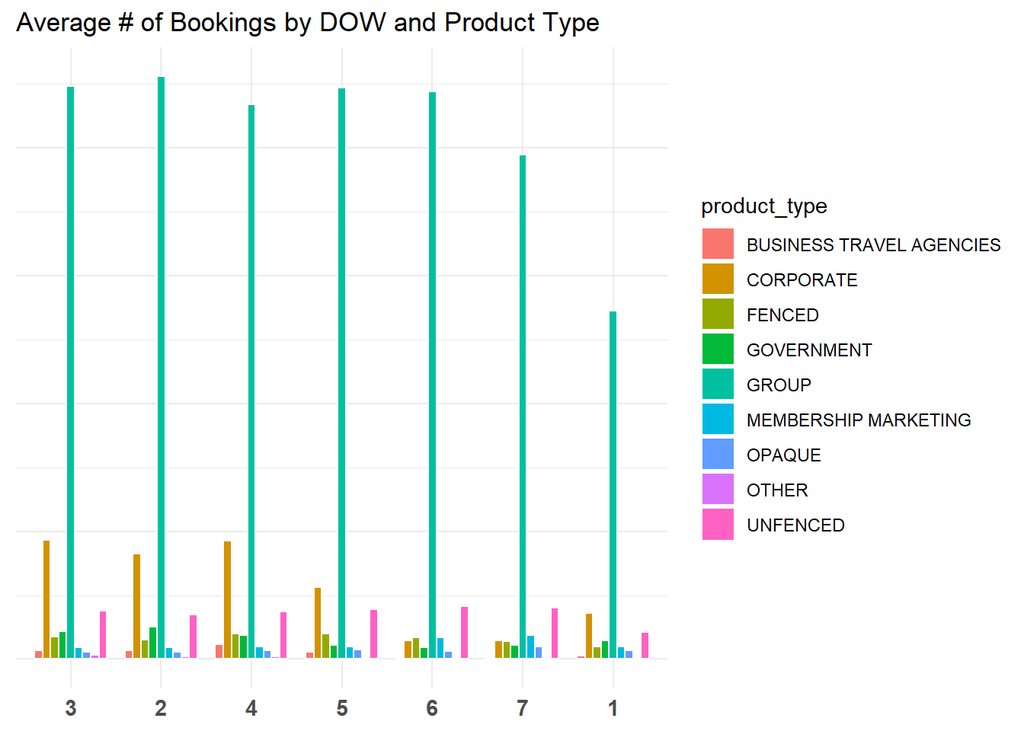

```r
#look at bookings by day of week and product type

h1_train %>%
  select(day_of_week, product_type, OTB) %>%
  group_by(day_of_week, product_type) %>%
  summarise(avg_bookings = mean(OTB)) %>%
  ggplot(aes(x = reorder(day_of_week, -avg_bookings), y = avg_bookings, fill = product_type)) +
           geom_bar(stat = "identity", width = .8, color = "white", position = "dodge") +
           theme_minimal() +
           theme(axis.title = element_blank(),
                axis.line.y = element_blank(),
                axis.ticks.y = element_blank(),
                axis.text.y = element_blank(),
                axis.text.x = element_text(size = 11, face = "bold")) +
           ggtitle("Average # of Bookings by DOW and Product Type")
```

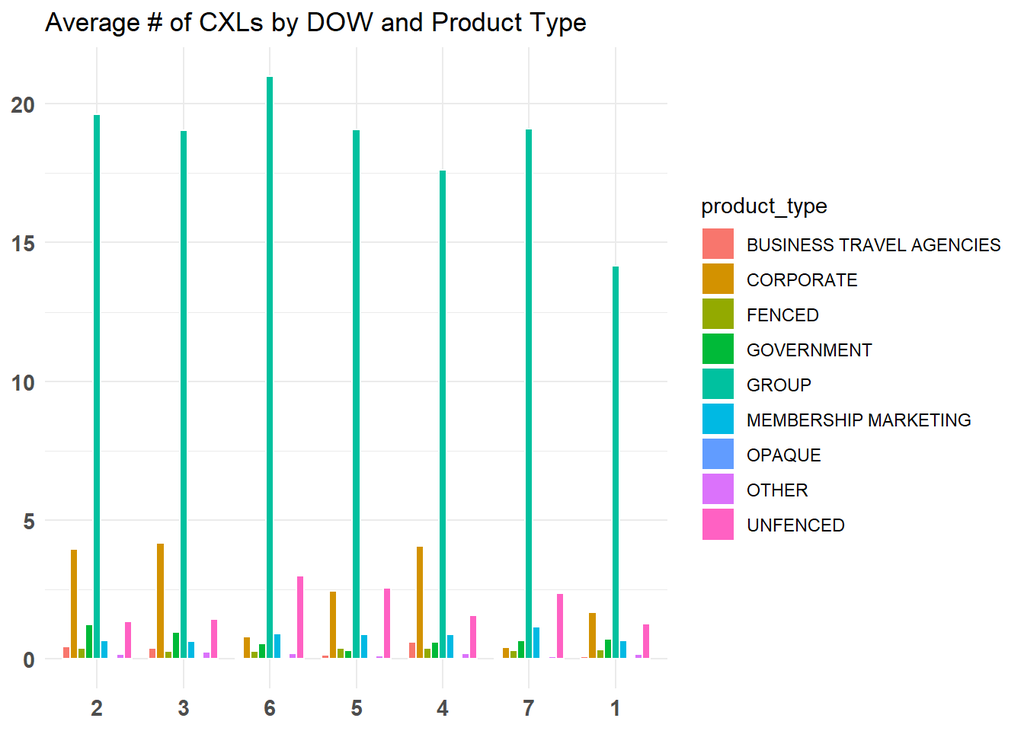

```r
#above by cancellations
h1_train %>%
  select(day_of_week, product_type, OTB_to_be_cxl) %>%
  group_by(day_of_week, product_type) %>%
  summarise(avg_cxl = mean(OTB_to_be_cxl)) %>%
  ggplot(aes(x = reorder(day_of_week, -avg_cxl), y = avg_cxl, fill = product_type)) +
           geom_bar(stat = "identity", width = .8, color = "white", position = "dodge") +
           theme_minimal() +
           theme(axis.title = element_blank(),
                axis.line.y = element_blank(),
                axis.ticks.y = element_blank(),
                axis.text.y = element_text(size = 11, face = "bold"),
                axis.text.x = element_text(size = 11, face = "bold")) +
           ggtitle("Average # of CXLs by DOW and Product Type")
```

Looking at the product types with cancellations in mind, the relations are very similar; however, it seems as though unfenced has a very high rate of cancellations. This makes sense due to the fact that these rooms are refundable so the consequences for cancelling are not high. Sundays are also the lowest day for cancellations and monday is the highest. Another griping of product type based off of behavior that we will try is as follows. - Group - Corporate - Unfenced - Other, Opaque, Fenced - Business Travel Agencies, Government, Membership Marketing

```r
#Create this group

h1_train_2 <- h1_train %>%
      mutate(prod_group_behav = case_when(product_type == 'OPAQUE' ~ 'OP/FENC/OTH',
                                         product_type == 'FENCED' ~ 'OP/FENC/OTH',
                                         product_type == 'CORPORATE' ~ 'CORPORATE',
                                         product_type == 'BUSINESS TRAVEL AGENCIES' ~ 'GOV/BUS/MEM',
                                         product_type == 'GROUP' ~ 'GROUP',
                                         product_type == 'MEMBERSHIP MARKETING' ~ 'GOV/BUS/MEM',
                                         product_type == 'OTHER' ~ 'OP/FENC/OTH',
                                         product_type == 'UNFENCED' ~ 'UNFENCED',
                                         product_type == 'GOVERNMENT' ~ 'GOV/BUS/MEM'))
```

To further look into grouping product type, we will look at the cancelation curve.

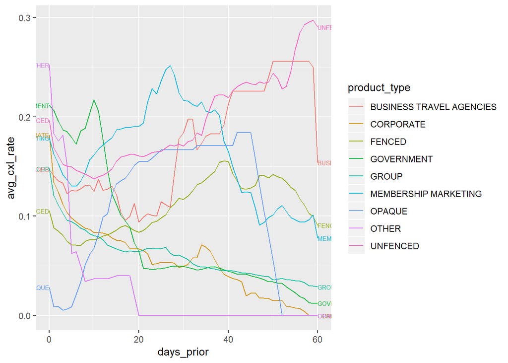

```r
h1_train %>%
  select(product_type, days_prior, cummulative_cxl_bookings, cummulative_gross_bookings) %>%
  filter(cummulative_gross_bookings != 0) %>%
  mutate(cxl_rate = cummulative_cxl_bookings/cummulative_gross_bookings) %>%
  group_by(days_prior, product_type) %>%
  summarise(avg_cxl_rate = mean(cxl_rate)) %>%
  ggplot()+
  geom_line(aes(x=days_prior, y=avg_cxl_rate, color = product_type))+
  geom_dl(aes(label = product_type, x=days_prior, y=avg_cxl_rate, color = product_type), method = list(dl.combine("first.points", "last.points"), cex=0.5))
```

It seems as though we should truncate the days prior to 30 as cancellations rates change significantly after this point. How many observations does each days prior have? What would happen to this graph if we tried this?

```r
h1_train %>%
  select(days_prior, daily_cxl_bookings) %>%
  group_by(days_prior) %>%
  summarize(num = sum(daily_cxl_bookings)) %>%
  kable(align = c("c", "c", "c", "c")) %>%
  kable_styling(bootstrap_options = c("striped", "condensed", "bordered")) %>%
  column_spec(1:2, color = "#000000")
```

| days_prior | num |
| --- | --- |
| 0 | 1613 |
| 1 | 535 |
| 2 | 449 |
| 3 | 340 |
| 4 | 238 |
| 5 | 214 |
| 6 | 167 |
| 7 | 167 |
| 8 | 158 |
| 9 | 118 |
| 10 | 74 |
| 11 | 88 |
| 12 | 109 |
| 13 | 127 |
| 14 | 111 |
| 15 | 108 |
| 16 | 82 |
| 17 | 63 |
| 18 | 99 |
| 19 | 77 |
| 20 | 70 |
| 21 | 69 |
| 22 | 57 |
| 23 | 53 |
| 24 | 52 |
| 25 | 50 |
| 26 | 49 |
| 27 | 56 |
| 28 | 61 |
| 29 | 62 |
| 30 | 55 |
| 31 | 56 |
| 32 | 57 |
| 33 | 41 |
| 34 | 34 |
| 35 | 35 |
| 36 | 37 |
| 37 | 41 |
| 38 | 44 |
| 39 | 23 |
| 40 | 25 |
| 41 | 27 |
| 42 | 23 |
| 43 | 16 |
| 44 | 20 |
| 45 | 21 |
| 46 | 19 |
| 47 | 17 |
| 48 | 21 |
| 49 | 39 |
| 50 | 20 |
| 51 | 14 |
| 52 | 20 |
| 53 | 16 |
| 54 | 16 |
| 55 | 20 |
| 56 | 17 |
| 57 | 16 |
| 58 | 12 |
| 59 | 17 |
| 60 | 9 |

- The amount of observations for each days prior goes down significantly after day 32. We will truncate the days prior here.

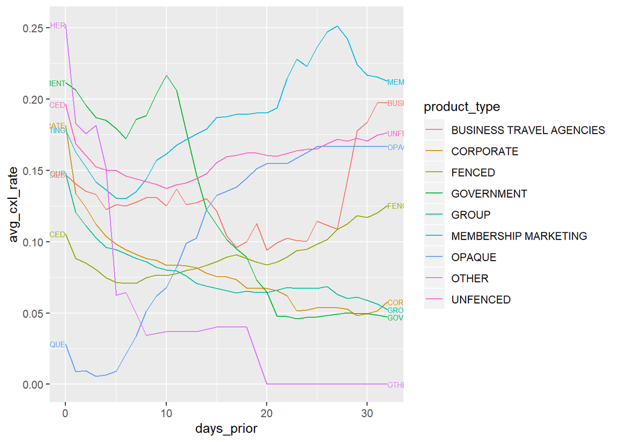

```r
h1_train %>%
  select(product_type, days_prior, cummulative_cxl_bookings, cummulative_gross_bookings) %>%
  filter(cummulative_gross_bookings != 0) %>%
  filter(days_prior <= 32) %>%
  mutate(cxl_rate = cummulative_cxl_bookings/cummulative_gross_bookings) %>%
  group_by(days_prior, product_type) %>%
  summarise(avg_cxl_rate = mean(cxl_rate)) %>%
  ggplot()+
  geom_line(aes(x=days_prior, y=avg_cxl_rate, color = product_type))+
  geom_dl(aes(label = product_type, x=days_prior, y=avg_cxl_rate, color = product_type), method = list(dl.combine("first.points", "last.points"), cex=0.5))
```

Based off of cancellation rates we can try to group similar groups together keeping in mind the number of cancellations each group has.

```r
# number of cancellations in each product type

h1_train %>%
  select(product_type, daily_cxl_bookings) %>%
  group_by(product_type) %>%
  summarize(num = sum(daily_cxl_bookings)) %>%
  kable(align = c("c", "c", "c", "c")) %>%
  kable_styling(bootstrap_options = c("striped", "condensed", "bordered")) %>%
  column_spec(1:2, color = "#000000")
```

| product_type | num |
| --- | --- |
| BUSINESS TRAVEL AGENCIES | 130 |
| CORPORATE | 1266 |
| FENCED | 124 |
| GOVERNMENT | 199 |
| GROUP | 3524 |
| MEMBERSHIP MARKETING | 260 |
| OPAQUE | 78 |
| OTHER | 22 |
| UNFENCED | 741 |

Since other and opaque has such a small amount of observations, these should definitely be joined with other product types. The third grouping method is based on the cancelation rate curve above. If the cxl curves are similar, we group the types into one.

-group 1: government 199, other 22 -group 2: unfenced 741, membership marketing 260, business travel agencies 130 -group 3: corporate 1266, fenced 124, -group 4: opaque 78 -group 5: group 3524

-Can we try unsupervised classification method?

```r
#Create this group

h1_train_3 <- h1_train %>%
      mutate(prod_group_cxl_rate = case_when(product_type == 'OPAQUE' ~ 'OP',
                                         product_type == 'FENCED' ~ 'FENC/CORP',
                                         product_type == 'CORPORATE' ~ 'FENC/CORP',
                                         product_type == 'BUSINESS TRAVEL AGENCIES' ~ 'UNF/MEM/BUS',
                                         product_type == 'GROUP' ~ 'GRP',
                                         product_type == 'MEMBERSHIP' ~ 'UNF/MEM/BUS',
                                         product_type == 'OTHER' ~ 'GOV/OTH',
                                         product_type == 'UNFENCED' ~ 'UNF/MEM/BUS',
                                         product_type == 'GOVERNMENT' ~ 'GOV/OTH'))
#truncate days prior to 32

h1_train_3 <- h1_train_3 %>%
            filter(days_prior <= 32)
```

##**Further Analysis**

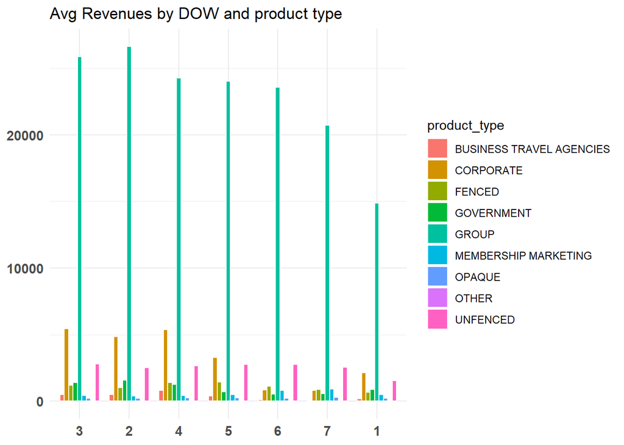

```r
#revenue by day of week

h1_train %>%
  select(day_of_week, product_type, OTB_rev) %>%
  group_by(day_of_week, product_type) %>%
  summarise(avg_rev = mean(OTB_rev)) %>%
  ggplot(aes(x = reorder(day_of_week, -avg_rev), y = avg_rev, fill = product_type)) +
           geom_bar(stat = "identity", width = .8, color = "white", position = "dodge") +
           theme_minimal() +
           theme(axis.title = element_blank(),
                axis.line.y = element_blank(),
                axis.ticks.y = element_blank(),
                axis.text.y = element_text(size = 11, face = "bold"),
                axis.text.x = element_text(size = 11, face = "bold")) +
           ggtitle("Avg Revenues by DOW and product type")
```

Sunday has the lowest on the book revenue. Since it is also the lowest dtay date, this makes sense, especially since the product type group has significantly less bookings for Sunday. It is evident that the ATL Hotel is focused on businesses and corporate events which is why group and corporate have the highest revenues. This is alsy why the weekend has less people staying at the hotel.

```r
#look into days prior with revenue and pricing

h1_train %>%
  select(OTB, OTB_to_be_cxl, OTB_rev, days_prior) %>%
  group_by(days_prior) %>%
  summarise(avg_bookings = mean(OTB),
            avg_cancels = mean(OTB_to_be_cxl),
            avg_otb_rev = mean(OTB_rev),
            avg_price = mean(OTB_rev)/ mean(OTB)) %>%
  arrange(desc(avg_otb_rev)) %>%
  kable(align = c("c", "c", "c", "c")) %>%
  kable_styling(bootstrap_options = c("striped", "condensed", "bordered")) %>%
  column_spec(1:4, color = "#000000")
```

| days_prior | avg_bookings | avg_cancels | avg_otb_rev | avg_price |
| --- | --- | --- | --- | --- |
| 0 | 67.23793 | 0.000000 | 7588.581 | 112.8616 |
| 1 | 64.29138 | 1.767241 | 7313.837 | 113.7608 |
| 2 | 62.53276 | 2.410345 | 7152.855 | 114.3857 |
| 3 | 61.14655 | 2.918966 | 7029.255 | 114.9575 |
| 4 | 59.77241 | 3.263793 | 6897.465 | 115.3955 |
| 5 | 58.42241 | 3.493103 | 6755.477 | 115.6316 |
| 6 | 57.07414 | 3.667241 | 6611.362 | 115.8381 |
| 7 | 55.81207 | 3.767241 | 6470.218 | 115.9287 |
| 8 | 54.60690 | 3.839655 | 6327.476 | 115.8732 |
| 9 | 53.54655 | 3.865517 | 6210.568 | 115.9845 |
| 10 | 52.37414 | 3.825862 | 6071.382 | 115.9233 |
| 11 | 51.24310 | 3.774138 | 5928.386 | 115.6914 |
| 12 | 50.60345 | 3.791379 | 5850.027 | 115.6053 |
| 13 | 49.74655 | 3.803448 | 5743.309 | 115.4514 |
| 14 | 48.68793 | 3.832759 | 5610.423 | 115.2323 |
| 15 | 47.55000 | 3.836207 | 5471.575 | 115.0699 |
| 16 | 46.28793 | 3.827586 | 5318.621 | 114.9030 |
| 17 | 45.03103 | 3.787931 | 5161.510 | 114.6212 |
| 18 | 44.01552 | 3.763793 | 5035.787 | 114.4094 |
| 19 | 43.00690 | 3.789655 | 4912.373 | 114.2229 |
| 20 | 41.84655 | 3.744828 | 4769.962 | 113.9870 |
| 21 | 40.60172 | 3.706897 | 4629.445 | 114.0209 |
| 22 | 38.80862 | 3.565517 | 4428.484 | 114.1108 |
| 23 | 36.93276 | 3.462069 | 4208.144 | 113.9407 |
| 24 | 35.05862 | 3.356897 | 3988.122 | 113.7558 |
| 25 | 33.29483 | 3.286207 | 3785.750 | 113.7039 |
| 26 | 31.66207 | 3.193103 | 3597.581 | 113.6243 |
| 27 | 30.51379 | 3.137931 | 3471.710 | 113.7751 |
| 28 | 29.32586 | 3.079310 | 3339.989 | 113.8923 |
| 29 | 28.04138 | 3.020690 | 3195.866 | 113.9696 |
| 30 | 27.27241 | 3.010345 | 3101.871 | 113.7366 |
| 31 | 26.48793 | 2.986207 | 3004.217 | 113.4183 |
| 32 | 25.78621 | 2.989655 | 2913.505 | 112.9869 |
| 33 | 25.19138 | 3.006897 | 2836.932 | 112.6152 |
| 34 | 24.50690 | 3.003448 | 2749.595 | 112.1968 |
| 35 | 23.81724 | 2.979310 | 2659.994 | 111.6835 |
| 36 | 23.19310 | 2.951724 | 2577.724 | 111.1418 |
| 37 | 22.58448 | 2.918966 | 2498.758 | 110.6405 |
| 38 | 22.03966 | 2.896552 | 2433.692 | 110.4233 |
| 39 | 21.53103 | 2.868965 | 2374.172 | 110.2674 |
| 40 | 21.01379 | 2.827586 | 2313.979 | 110.1171 |
| 41 | 20.50000 | 2.786207 | 2252.342 | 109.8703 |
| 42 | 20.01207 | 2.753448 | 2190.311 | 109.4495 |
| 43 | 19.52586 | 2.732759 | 2131.014 | 109.1380 |
| 44 | 19.13793 | 2.694828 | 2084.028 | 108.8952 |
| 45 | 18.76552 | 2.665517 | 2039.240 | 108.6695 |
| 46 | 18.33448 | 2.606897 | 1992.633 | 108.6823 |
| 47 | 17.88448 | 2.543103 | 1941.593 | 108.5630 |
| 48 | 17.32241 | 2.477586 | 1875.688 | 108.2810 |
| 49 | 16.66724 | 2.410345 | 1797.842 | 107.8668 |
| 50 | 15.95862 | 2.374138 | 1713.660 | 107.3815 |
| 51 | 15.34310 | 2.322414 | 1643.016 | 107.0850 |
| 52 | 14.87586 | 2.272414 | 1591.905 | 107.0126 |
| 53 | 14.42586 | 2.231034 | 1544.552 | 107.0683 |
| 54 | 13.98966 | 2.186207 | 1498.422 | 107.1093 |
| 55 | 13.59483 | 2.146552 | 1456.180 | 107.1128 |
| 56 | 13.18276 | 2.113793 | 1412.236 | 107.1275 |
| 57 | 12.81207 | 2.067241 | 1373.093 | 107.1718 |
| 58 | 12.48448 | 2.010345 | 1339.991 | 107.3325 |
| 59 | 12.08276 | 1.950000 | 1299.955 | 107.5876 |
| 60 | 11.62414 | 1.867241 | 1250.307 | 107.5613 |

```r
#look into price by product type
h1_train %>%
  select(product_type,  OTB, OTB_to_be_cxl, OTB_rev) %>%
  group_by(product_type) %>%
  summarise(avg_bookings = mean(OTB),
            avg_cancels = mean(OTB_to_be_cxl),
            avg_rev = mean(OTB_rev),
             avg_price = mean(OTB_rev)/ mean(OTB)) %>%
  kable(align = c("c", "c", "c")) %>%
  kable_styling(bootstrap_options = c("striped", "condensed", "bordered")) %>%
  column_spec(1:3, color = "#000000")
```

| product_type | avg_bookings | avg_cancels | avg_rev | avg_price |
| --- | --- | --- | --- | --- |
| BUSINESS TRAVEL AGENCIES | 2.720271 | 0.2589123 | 383.6063232 | 141.0177061 |
| CORPORATE | 27.358486 | 2.4672131 | 3194.1931533 | 116.7532864 |
| FENCED | 8.092334 | 0.3404050 | 1110.7664055 | 137.2615679 |
| GOVERNMENT | 7.846914 | 0.7222758 | 982.6340501 | 125.2255381 |
| GROUP | 206.284957 | 18.4956606 | 22745.8354677 | 110.2641503 |
| MEMBERSHIP MARKETING | 6.021287 | 0.8438953 | 583.7186665 | 96.9425084 |
| OPAQUE | 3.436570 | 0.0375788 | 241.4971400 | 70.2727257 |
| OTHER | 0.771949 | 0.1672131 | 0.0447286 | 0.0579424 |
| UNFENCED | 17.964561 | 1.9575699 | 2513.3208052 | 139.9043802 |

Why would other be so low? I am suprised at the close price between unfenced and fenced. It is interesting that business travel agencies has the highest average price. It does make sense that group has a lower price as they are usually booking big chunks. Price should be included as a variable in future modeling

```r
#add price to h1_train

h1_train <-  h1_train %>%
  mutate(price = OTB_rev/OTB)
```

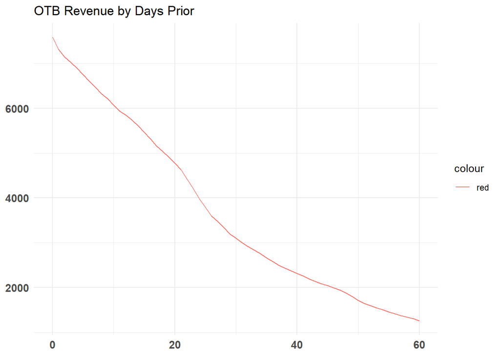

```r
#net revenue and days prior

h1_train %>%
  select(days_prior, OTB, OTB_to_be_cxl, OTB_rev) %>%
  group_by(days_prior) %>%
  summarise(avg_net_rev = mean(OTB_rev)) %>%
  ggplot() +
  geom_line(aes(x = days_prior, y = avg_net_rev, color = "red")) +
           theme_minimal() +
           theme(axis.title = element_blank(),
                axis.line.y = element_blank(),
                axis.ticks.y = element_blank(),
                axis.text.y = element_text(size = 11, face = "bold"),
                axis.text.x = element_text(size = 11, face = "bold")) +
           ggtitle("OTB Revenue by Days Prior")
```

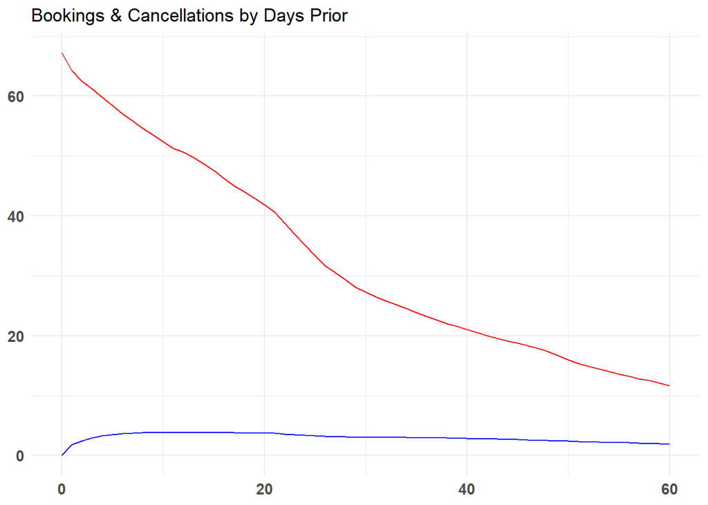

```r
#graphical representation of above

h1_train %>%
  select(days_prior, OTB, OTB_to_be_cxl, OTB_rev) %>%
  group_by(days_prior) %>%
  summarise(avg_net_rev = mean(OTB_rev),
            avg_bookings = mean(OTB),
            avg_cxl = mean(OTB_to_be_cxl)) %>%
  ggplot() +
  geom_line(aes(x = days_prior, y = avg_bookings), color = "red") +
  geom_line(aes(x = days_prior, y = avg_cxl), color = "blue") +
           theme_minimal() +
           theme(axis.title = element_blank(),
                axis.line.y = element_blank(),
                axis.ticks.y = element_blank(),
                axis.text.y = element_text(size = 11, face = "bold"),
                axis.text.x = element_text(size = 11, face = "bold")) +
           ggtitle("Bookings & Cancellations by Days Prior")
```

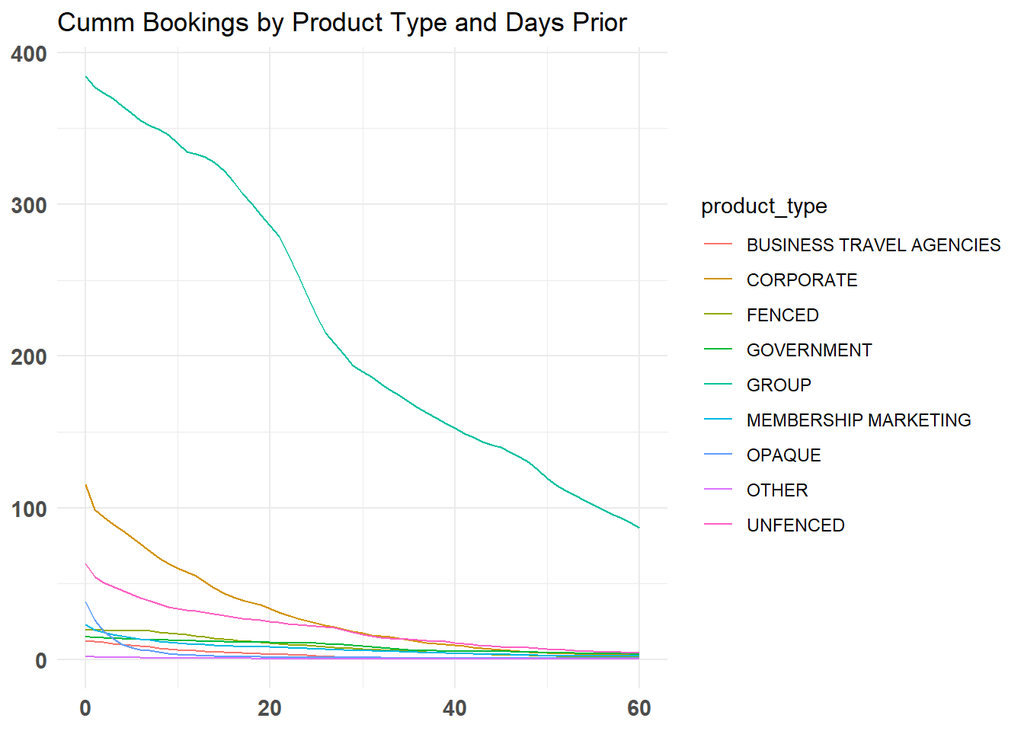

```r
h1_train %>%
  select(days_prior, cummulative_gross_bookings, product_type) %>%
  group_by(days_prior, product_type) %>%
  summarise(avg_bookings = mean(cummulative_gross_bookings)) %>%
  ggplot() +
  geom_line(aes(x = days_prior, y = avg_bookings,  color = product_type)) +
           theme_minimal() +
           theme(axis.title = element_blank(),
                axis.line.y = element_blank(),
                axis.ticks.y = element_blank(),
                axis.text.y = element_text(size = 11, face = "bold"),
                axis.text.x = element_text(size = 11, face = "bold")) +
           ggtitle("Cumm Bookings by Product Type and Days Prior")
```

You can see a steeper increase around prior day zero on most product types.

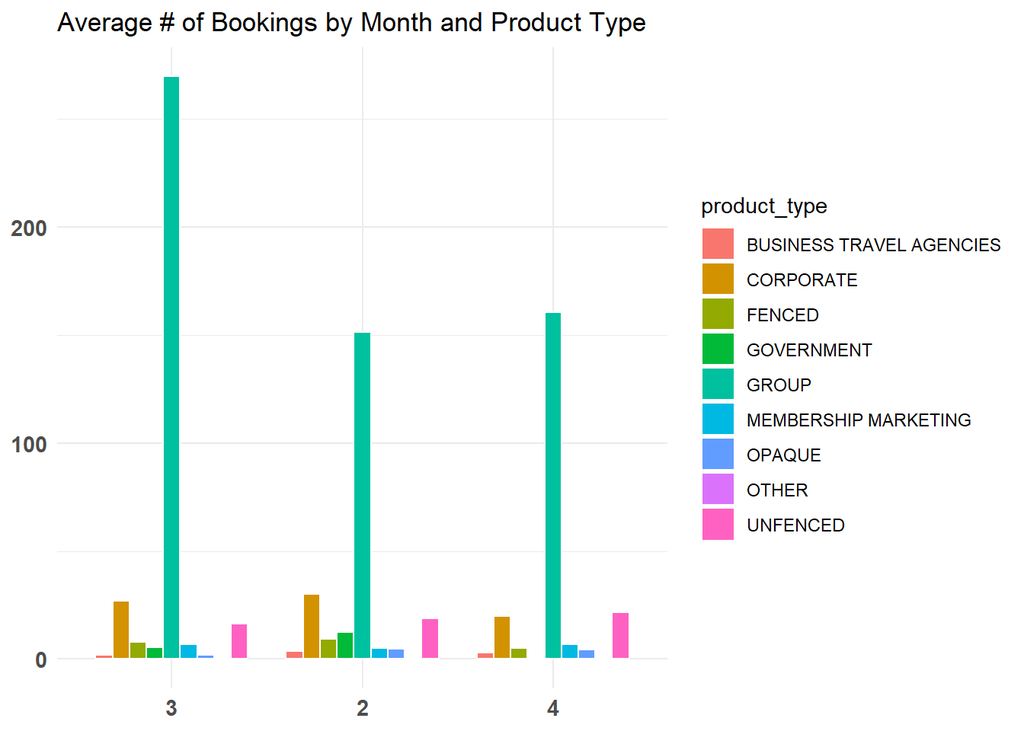

```r
#How does month affect bookings and cancellations
h1_train$month = month(h1_train$stay_dt)

h1_train %>%
  select(month, product_type, OTB) %>%
  group_by(month, product_type) %>%
  summarise(avg_bookings = mean(OTB)) %>%
  ggplot(aes(x = reorder(month, -avg_bookings), y = avg_bookings, fill = product_type)) +
           geom_bar(stat = "identity", width = .8, color = "white", position = "dodge") +
           theme_minimal() +
           theme(axis.title = element_blank(),
                axis.line.y = element_blank(),
                axis.ticks.y = element_blank(),
                axis.text.y = element_text(size = 11, face = "bold"),
                axis.text.x = element_text(size = 11, face = "bold")) +
           ggtitle("Average # of Bookings by Month and Product Type")
```

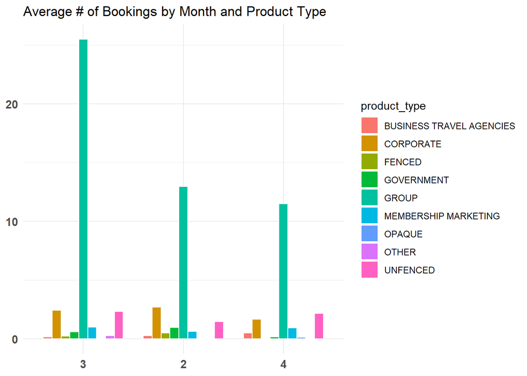

```r
h1_train %>%
  select(month, product_type, OTB_to_be_cxl) %>%
  group_by(month, product_type) %>%
  summarise(avg_bookings = mean(OTB_to_be_cxl)) %>%
  ggplot(aes(x = reorder(month, -avg_bookings), y = avg_bookings, fill = product_type)) +
           geom_bar(stat = "identity", width = .8, color = "white", position = "dodge") +
           theme_minimal() +
           theme(axis.title = element_blank(),
                axis.line.y = element_blank(),
                axis.ticks.y = element_blank(),
                axis.text.y = element_text(size = 11, face = "bold"),
                axis.text.x = element_text(size = 11, face = "bold")) +
           ggtitle("Average # of Bookings by Month and Product Type")
```

##**Outliers**

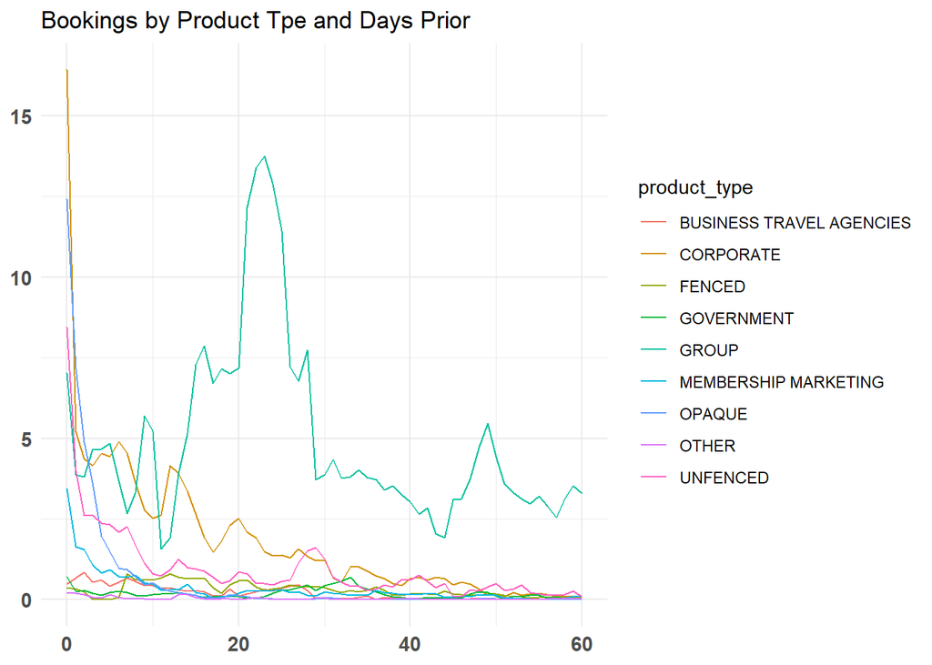

```r
h1_train %>%
  select(days_prior, daily_gross_bookings, product_type) %>%
  group_by(days_prior, product_type) %>%
  summarise(avg_bookings = mean(daily_gross_bookings)) %>%
  ggplot() +
  geom_line(aes(x = days_prior, y = avg_bookings,  color = product_type)) +
           theme_minimal() +
           theme(axis.title = element_blank(),
                axis.line.y = element_blank(),
                axis.ticks.y = element_blank(),
                axis.text.y = element_text(size = 11, face = "bold"),
                axis.text.x = element_text(size = 11, face = "bold")) +
           ggtitle("Bookings by Product Tpe and Days Prior")
```

To look for outliers, I am using daily gross bookings to see if you can see any quick increases. It looks as though there is a big spike in group around day 23. It also seems as though there are just big increases on day of bookings. If these are outliers, we may not want to get rid of them since it looks like a common trend is a spike in day of bookings.

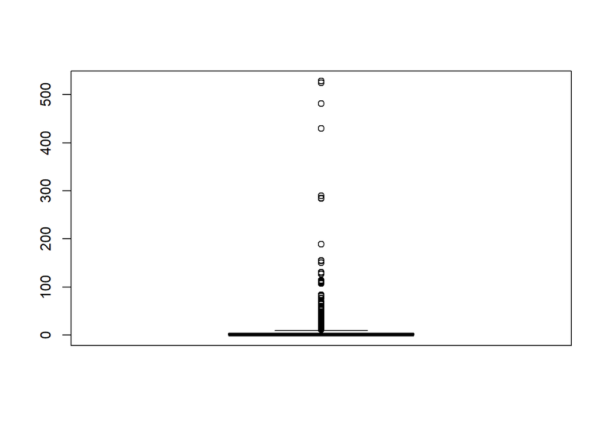

```r
#looking into outliers
group_outlier <- h1_train %>%
                filter(product_type == 'GROUP')

group_outlier <- boxplot(group_outlier$daily_gross_bookings)$out
```

```r
h1_train %>%
  select(product_type, days_prior, daily_gross_bookings) %>%
  filter(product_type == 'GROUP') %>%
  filter(daily_gross_bookings > 300)
```

```
## # A tibble: 4 x 3
##   product_type days_prior daily_gross_bookings
##   <chr>             <dbl>                <dbl>
## 1 GROUP                22                  481
## 2 GROUP                23                  528
## 3 GROUP                24                  525
## 4 GROUP                25                  430
```

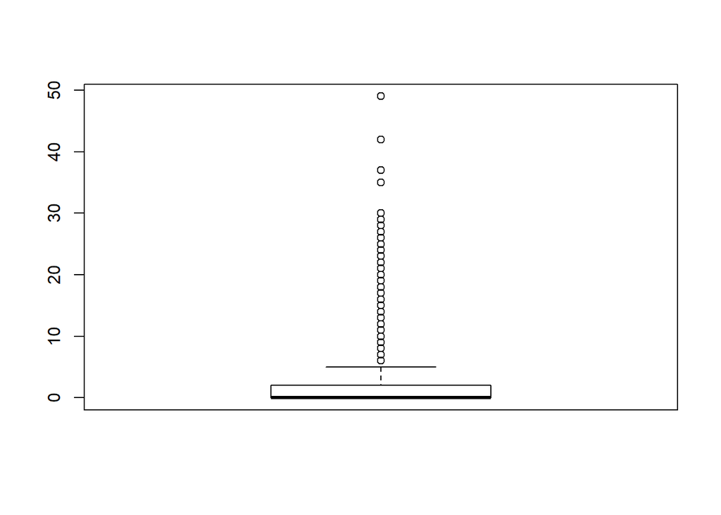

```r
corp_outlier <- h1_train %>%
                filter(product_type == 'CORPORATE')

corp_outlier <- boxplot(corp_outlier$daily_gross_bookings)$out
```

```r
h1_train %>%
  select(product_type, days_prior, daily_gross_bookings) %>%
  filter(product_type == 'CORPORATE') %>%
  filter(daily_gross_bookings > 20)
```

```
## # A tibble: 42 x 3
##    product_type days_prior daily_gross_bookings
##    <chr>             <dbl>                <dbl>
##  1 CORPORATE             0                   27
##  2 CORPORATE             0                   24
##  3 CORPORATE             0                   25
##  4 CORPORATE             0                   23
##  5 CORPORATE             0                   21
##  6 CORPORATE             0                   29
##  7 CORPORATE             4                   23
##  8 CORPORATE             0                   28
##  9 CORPORATE             2                   23
## 10 CORPORATE             0                   24
## # ... with 32 more rows
```

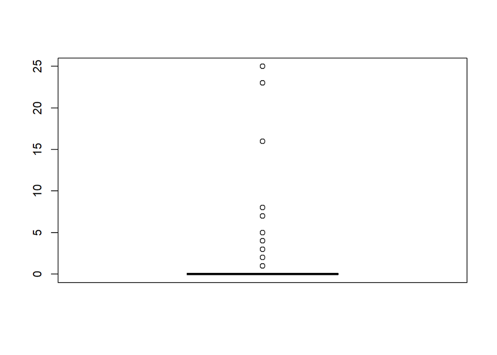

```r
gov_outlier <- h1_train %>%
                filter(product_type == 'GOVERNMENT')

gov_outlier <- boxplot(gov_outlier$daily_gross_bookings)$out
```

```r
h1_train %>%
  select(product_type, days_prior, daily_gross_bookings) %>%
  filter(product_type == 'GOVERNMENT') %>%
  filter(daily_gross_bookings > 10)
```

```
## # A tibble: 4 x 3
##   product_type days_prior daily_gross_bookings
##   <chr>             <dbl>                <dbl>
## 1 GOVERNMENT           30                   16
## 2 GOVERNMENT           31                   23
## 3 GOVERNMENT           32                   25
## 4 GOVERNMENT           33                   23
```

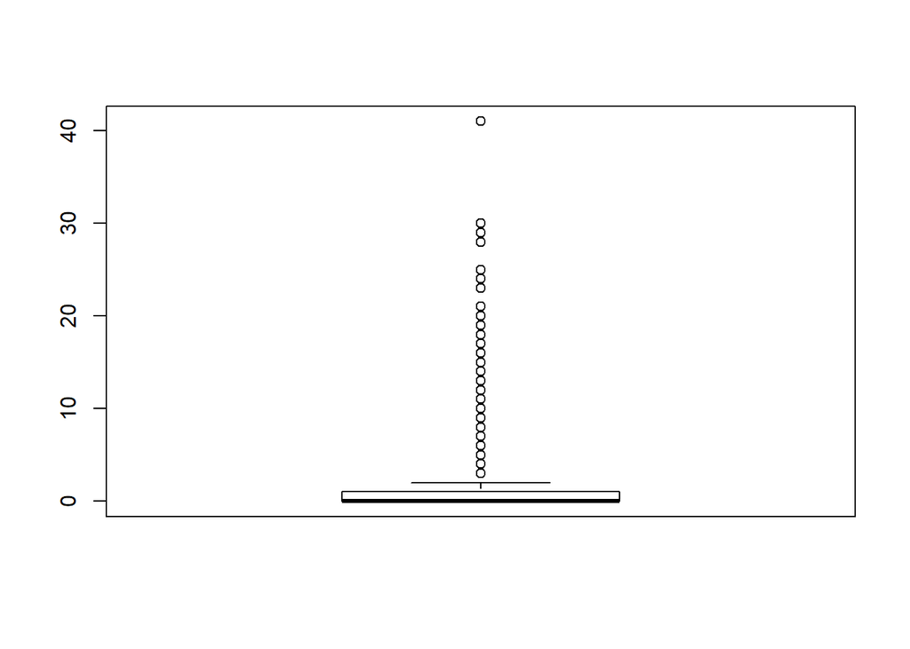

```r
unf_outlier <- h1_train %>%
                filter(product_type == 'UNFENCED')

unf_outlier <- boxplot(unf_outlier$daily_gross_bookings)$out
```

```r
h1_train %>%
  select(product_type, days_prior, daily_gross_bookings) %>%
  filter(product_type == 'UNFENCED') %>%
  filter(daily_gross_bookings > 30)
```

```
## # A tibble: 1 x 3
##   product_type days_prior daily_gross_bookings
##   <chr>             <dbl>                <dbl>
## 1 UNFENCED              7                   41
```

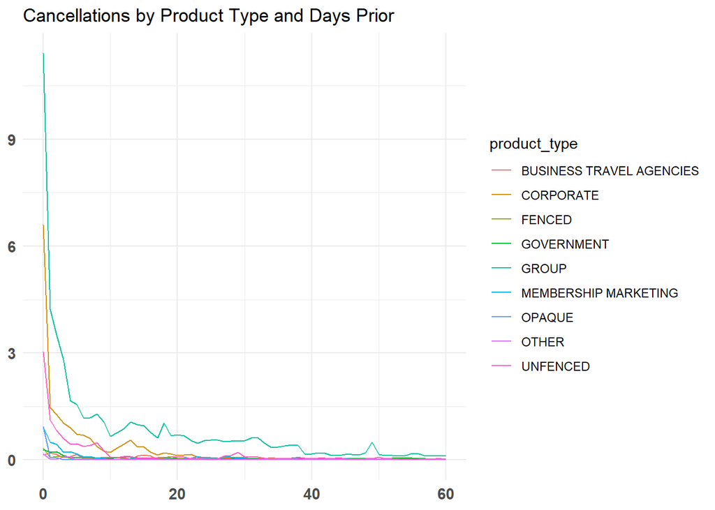

```r
#look into cancellations
h1_train %>%
  select(days_prior, daily_cxl_bookings, product_type) %>%
  group_by(days_prior, product_type) %>%
  summarise(avg_bookings = mean(daily_cxl_bookings)) %>%
  ggplot() +
  geom_line(aes(x = days_prior, y = avg_bookings, fill = product_type, color = product_type)) +
           theme_minimal() +
           theme(axis.title = element_blank(),
                axis.line.y = element_blank(),
                axis.ticks.y = element_blank(),
                axis.text.y = element_text(size = 11, face = "bold"),
                axis.text.x = element_text(size = 11, face = "bold")) +
           ggtitle("Cancellations by Product Type and Days Prior")
```

There seems to be no big bumps except for the day of. Since we are dealing with daily gross cancellations, it seems as though there are a lot of people that cancel the day of. We should include these observations since this is a common trend.

##**Correlations**

```r
#look into correlations to prepare for linear regressions
h1_train %>%
  select(dow, days_prior, cummulative_cxl_bookings, cummulative_gross_bookings, cummulative_gross_rev, OTB, OTB_rev, OTB_to_be_cxl, month, price)%>%
  cor()
```

```
##                                     dow  days_prior
## dow                         1.000000000  0.00000000
## days_prior                  0.000000000  1.00000000
## cummulative_cxl_bookings   -0.002316593 -0.25679557
## cummulative_gross_bookings  0.006939249 -0.17994121
## cummulative_gross_rev      -0.002211240 -0.18203236
## OTB                         0.007574081 -0.17049315
## OTB_rev                    -0.001960750 -0.17216109
## OTB_to_be_cxl               0.011932276 -0.04519631
## month                      -0.012737670  0.00000000
## price                                NA          NA
##                            cummulative_cxl_bookings
## dow                                    -0.002316593
## days_prior                             -0.256795567
## cummulative_cxl_bookings                1.000000000
## cummulative_gross_bookings              0.799722584
## cummulative_gross_rev                   0.765420599
## OTB                                     0.769285256
## OTB_rev                                 0.738805326
## OTB_to_be_cxl                           0.499983171
## month                                   0.063400263
## price                                            NA
##                            cummulative_gross_bookings
## dow                                       0.006939249
## days_prior                               -0.179941207
## cummulative_cxl_bookings                  0.799722584
## cummulative_gross_bookings                1.000000000
## cummulative_gross_rev                     0.991306644
## OTB                                       0.998794282
## OTB_rev                                   0.989089917
## OTB_to_be_cxl                             0.837094530
## month                                     0.023198097
## price                                              NA
##                            cummulative_gross_rev          OTB      OTB_rev
## dow                                  -0.00221124  0.007574081 -0.001960750
## days_prior                           -0.18203236 -0.170493153 -0.172161086
## cummulative_cxl_bookings              0.76542060  0.769285256  0.738805326
## cummulative_gross_bookings            0.99130664  0.998794282  0.989089917
## cummulative_gross_rev                 1.00000000  0.992347764  0.999040558
## OTB                                   0.99234776  1.000000000  0.992165054
## OTB_rev                               0.99904056  0.992165054  1.000000000
## OTB_to_be_cxl                         0.82109460  0.849941805  0.830682400
## month                                -0.00137675  0.019502937 -0.002726785
## price                                         NA           NA           NA
##                            OTB_to_be_cxl        month price
## dow                           0.01193228 -0.012737670    NA
## days_prior                   -0.04519631  0.000000000    NA
## cummulative_cxl_bookings      0.49998317  0.063400263    NA
## cummulative_gross_bookings    0.83709453  0.023198097    NA
## cummulative_gross_rev         0.82109460 -0.001376750    NA
## OTB                           0.84994180  0.019502937    NA
## OTB_rev                       0.83068240 -0.002726785    NA
## OTB_to_be_cxl                 1.00000000  0.027315190    NA
## month                         0.02731519  1.000000000    NA
## price                                 NA           NA     1
```

- Cummulative cancellations and cummulative gross bookings have a very high correlation along with revenue
- Month does not seem to have any significant correlations
- cummulative_cxl_bookings,cummulative_gross_bookings,cummulative_gross_rev,OTB,OTB_rev are highly correlated. So the models will use one of them each time.

##**Linear Regression**

```r
# Grouping Method 1:
## h1_train_1: prod_group_perc, dow, days_prior, one of (cummulative_gross_bookings,cummulative_gross_rev,cummulative_cxl_bookings,cummulative_cxl_rev,OTB,OTB_rev)
h1_train_1$month <- month(h1_train_1$stay_dt)

mod1 <- lm(OTB_to_be_cxl~days_prior+day_of_week+month+prod_group_perc+cummulative_cxl_bookings, data=h1_train_1)
mod2 <- lm(OTB_to_be_cxl~days_prior+day_of_week+month+prod_group_perc+cummulative_gross_bookings, data=h1_train_1)
mod3 <- lm(OTB_to_be_cxl~days_prior+day_of_week+month+prod_group_perc+cummulative_gross_rev, data=h1_train_1)
mod4 <- lm(OTB_to_be_cxl~days_prior+day_of_week+month+prod_group_perc+OTB, data=h1_train_1)

summary(mod1)
```

```
##
## Call:
## lm(formula = OTB_to_be_cxl ~ days_prior + day_of_week + month +
##     prod_group_perc + cummulative_cxl_bookings, data = h1_train_1)
##
## Residuals:
##     Min      1Q  Median      3Q     Max
## -43.142  -1.083  -0.322   0.500  66.032
##
## Coefficients:
##                             Estimate Std. Error t value
## (Intercept)               -0.2376124  0.1905553  -1.247
## days_prior                -0.0002509  0.0020511  -0.122
## day_of_week2               1.0277725  0.1296628   7.927
## day_of_week3               0.9380420  0.1307240   7.176
## day_of_week4               0.7085235  0.1273194   5.565
## day_of_week5               0.7559333  0.1272709   5.940
## day_of_week6               0.9419694  0.1263431   7.456
## day_of_week7               0.6076164  0.1260189   4.822
## month                      0.2568054  0.0518682   4.951
## prod_group_percGOV/UNFENC -0.1429267  0.0949803  -1.505
## prod_group_percGROUP      14.8738183  0.1346402 110.471
## prod_group_percMEM/OTHER  -0.9911415  0.1345376  -7.367
## prod_group_percOP/FENC    -1.0325080  0.0955937 -10.801
## cummulative_cxl_bookings   0.1733968  0.0053193  32.598
##                                       Pr(>|t|)
## (Intercept)                              0.212
## days_prior                               0.903
## day_of_week2               0.00000000000000233 ***
## day_of_week3               0.00000000000073512 ***
## day_of_week4               0.00000002644034917 ***
## day_of_week5               0.00000000288800670 ***
## day_of_week6               0.00000000000009174 ***
## day_of_week7               0.00000143058462633 ***
## month                      0.00000074172945309 ***
## prod_group_percGOV/UNFENC                0.132
## prod_group_percGROUP      < 0.0000000000000002 ***
## prod_group_percMEM/OTHER   0.00000000000017879 ***
## prod_group_percOP/FENC    < 0.0000000000000002 ***
## cummulative_cxl_bookings  < 0.0000000000000002 ***
## ---
## Signif. codes:  0 '***' 0.001 '**' 0.01 '*' 0.05 '.' 0.1 ' ' 1
##
## Residual standard error: 6.055 on 31279 degrees of freedom
##   (4087 observations deleted due to missingness)
## Multiple R-squared:  0.5057, Adjusted R-squared:  0.5055
## F-statistic:  2462 on 13 and 31279 DF,  p-value: < 0.00000000000000022
```

```r
summary(mod2)
```

```
##
## Call:
## lm(formula = OTB_to_be_cxl ~ days_prior + day_of_week + month +
##     prod_group_perc + cummulative_gross_bookings, data = h1_train_1)
##
## Residuals:
##     Min      1Q  Median      3Q     Max
## -63.635  -1.007  -0.218   0.755  52.145
##
## Coefficients:
##                              Estimate Std. Error t value
## (Intercept)                -1.2636195  0.1378002  -9.170
## days_prior                  0.0424537  0.0014522  29.234
## day_of_week2                0.1361741  0.0938496   1.451
## day_of_week3                0.0255447  0.0946118   0.270
## day_of_week4               -0.1378603  0.0920877  -1.497
## day_of_week5                0.0051148  0.0920806   0.056
## day_of_week6                0.3286542  0.0913966   3.596
## day_of_week7                0.1569450  0.0911331   1.722
## month                       0.1364287  0.0373435   3.653
## prod_group_percGOV/UNFENC   0.0521935  0.0686292   0.761
## prod_group_percGROUP        5.5925252  0.1065389  52.493
## prod_group_percMEM/OTHER   -0.3548762  0.0972541  -3.649
## prod_group_percOP/FENC     -0.6122101  0.0690864  -8.862
## cummulative_gross_bookings  0.0564636  0.0003227 174.966
##                                        Pr(>|t|)
## (Intercept)                < 0.0000000000000002 ***
## days_prior                 < 0.0000000000000002 ***
## day_of_week2                           0.146795
## day_of_week3                           0.787166
## day_of_week4                           0.134389
## day_of_week5                           0.955703
## day_of_week6                           0.000324 ***
## day_of_week7                           0.085052 .
## month                                  0.000259 ***
## prod_group_percGOV/UNFENC              0.446953
## prod_group_percGROUP       < 0.0000000000000002 ***
## prod_group_percMEM/OTHER               0.000264 ***
## prod_group_percOP/FENC     < 0.0000000000000002 ***
## cummulative_gross_bookings < 0.0000000000000002 ***
## ---
## Signif. codes:  0 '***' 0.001 '**' 0.01 '*' 0.05 '.' 0.1 ' ' 1
##
## Residual standard error: 4.377 on 31279 degrees of freedom
##   (4087 observations deleted due to missingness)
## Multiple R-squared:  0.7417, Adjusted R-squared:  0.7416
## F-statistic:  6910 on 13 and 31279 DF,  p-value: < 0.00000000000000022
```

```r
summary(mod3)
```

```
##
## Call:
## lm(formula = OTB_to_be_cxl ~ days_prior + day_of_week + month +
##     prod_group_perc + cummulative_gross_rev, data = h1_train_1)
##
## Residuals:
##     Min      1Q  Median      3Q     Max
## -64.072  -0.972  -0.229   0.714  53.210
##
## Coefficients:
##                               Estimate   Std. Error t value
## (Intercept)               -1.848351440  0.139718035 -13.229
## days_prior                 0.039676856  0.001467068  27.045
## day_of_week2               0.128360181  0.095002372   1.351
## day_of_week3               0.029477539  0.095769637   0.308
## day_of_week4              -0.072978564  0.093191036  -0.783
## day_of_week5               0.107647015  0.093175020   1.155
## day_of_week6               0.461080973  0.092482204   4.986
## day_of_week7               0.295455945  0.092223062   3.204
## month                      0.368393355  0.037763440   9.755
## prod_group_percGOV/UNFENC -0.062763166  0.069463871  -0.904
## prod_group_percGROUP       6.953395364  0.103590137  67.124
## prod_group_percMEM/OTHER  -0.337199603  0.098448802  -3.425
## prod_group_percOP/FENC    -0.627320261  0.069926796  -8.971
## cummulative_gross_rev      0.000461740  0.000002705 170.676
##                                       Pr(>|t|)
## (Intercept)               < 0.0000000000000002 ***
## days_prior                < 0.0000000000000002 ***
## day_of_week2                          0.176665
## day_of_week3                          0.758239
## day_of_week4                          0.433570
## day_of_week5                          0.247968
## day_of_week6                       0.000000621 ***
## day_of_week7                          0.001358 **
## month                     < 0.0000000000000002 ***
## prod_group_percGOV/UNFENC             0.366248
## prod_group_percGROUP      < 0.0000000000000002 ***
## prod_group_percMEM/OTHER              0.000615 ***
## prod_group_percOP/FENC    < 0.0000000000000002 ***
## cummulative_gross_rev     < 0.0000000000000002 ***
## ---
## Signif. codes:  0 '***' 0.001 '**' 0.01 '*' 0.05 '.' 0.1 ' ' 1
##
## Residual standard error: 4.431 on 31279 degrees of freedom
##   (4087 observations deleted due to missingness)
## Multiple R-squared:  0.7354, Adjusted R-squared:  0.7353
## F-statistic:  6687 on 13 and 31279 DF,  p-value: < 0.00000000000000022
```

```r
summary(mod4)
```

```
##
## Call:
## lm(formula = OTB_to_be_cxl ~ days_prior + day_of_week + month +
##     prod_group_perc + OTB, data = h1_train_1)
##
## Residuals:
##     Min      1Q  Median      3Q     Max
## -60.567  -0.991  -0.215   0.725  52.324
##
## Coefficients:
##                             Estimate Std. Error t value
## (Intercept)               -1.2840622  0.1329044  -9.662
## days_prior                 0.0409309  0.0013958  29.325
## day_of_week2               0.0965491  0.0905212   1.067
## day_of_week3              -0.0106952  0.0912547  -0.117
## day_of_week4              -0.1542369  0.0888132  -1.737
## day_of_week5              -0.0246111  0.0888135  -0.277
## day_of_week6               0.2944848  0.0881566   3.340
## day_of_week7               0.1297597  0.0879018   1.476
## month                      0.1691715  0.0360094   4.698
## prod_group_percGOV/UNFENC  0.0954866  0.0661968   1.442
## prod_group_percGROUP       5.2962579  0.1024096  51.716
## prod_group_percMEM/OTHER  -0.3522593  0.0937969  -3.756
## prod_group_percOP/FENC    -0.6155168  0.0666296  -9.238
## OTB                        0.0618214  0.0003293 187.748
##                                       Pr(>|t|)
## (Intercept)               < 0.0000000000000002 ***
## days_prior                < 0.0000000000000002 ***
## day_of_week2                          0.286165
## day_of_week3                          0.906701
## day_of_week4                          0.082460 .
## day_of_week5                          0.781698
## day_of_week6                          0.000837 ***
## day_of_week7                          0.139903
## month                               0.00000264 ***
## prod_group_percGOV/UNFENC             0.149181
## prod_group_percGROUP      < 0.0000000000000002 ***
## prod_group_percMEM/OTHER              0.000173 ***
## prod_group_percOP/FENC    < 0.0000000000000002 ***
## OTB                       < 0.0000000000000002 ***
## ---
## Signif. codes:  0 '***' 0.001 '**' 0.01 '*' 0.05 '.' 0.1 ' ' 1
##
## Residual standard error: 4.222 on 31279 degrees of freedom
##   (4087 observations deleted due to missingness)
## Multiple R-squared:  0.7597, Adjusted R-squared:  0.7596
## F-statistic:  7608 on 13 and 31279 DF,  p-value: < 0.00000000000000022
```

```r
# Grouping Method 2:
# h1_train_2: prod_group_behav, dow, days_prior, one of (cummulative_gross_bookings,cummulative_gross_rev,cummulative_cxl_bookings,cummulative_cxl_rev,OTB,OTB_rev)
h1_train_2$month <- month(h1_train_2$stay_dt)

mod1 <- lm(OTB_to_be_cxl~days_prior+day_of_week+month+prod_group_behav+cummulative_cxl_bookings, data=h1_train_2)
mod2 <- lm(OTB_to_be_cxl~days_prior+day_of_week+month+prod_group_behav+cummulative_gross_bookings, data=h1_train_2)
mod3 <- lm(OTB_to_be_cxl~days_prior+day_of_week+month+prod_group_behav+cummulative_gross_rev, data=h1_train_2)
mod4 <- lm(OTB_to_be_cxl~days_prior+day_of_week+month+prod_group_behav+OTB, data=h1_train_2)

summary(mod1)
```

```
##
## Call:
## lm(formula = OTB_to_be_cxl ~ days_prior + day_of_week + month +
##     prod_group_behav + cummulative_cxl_bookings, data = h1_train_2)
##
## Residuals:
##     Min      1Q  Median      3Q     Max
## -41.847  -0.745  -0.272   0.432  66.095
##
## Coefficients:
##                              Estimate Std. Error t value
## (Intercept)                  0.756865   0.179655   4.213
## days_prior                  -0.002350   0.001806  -1.301
## day_of_week2                 0.930597   0.114451   8.131
## day_of_week3                 0.869984   0.115254   7.548
## day_of_week4                 0.690073   0.112614   6.128
## day_of_week5                 0.728751   0.112208   6.495
## day_of_week6                 0.870523   0.111477   7.809
## day_of_week7                 0.585625   0.111154   5.269
## month                        0.276211   0.045702   6.044
## prod_group_behavGOV/BUS/MEM -1.633265   0.102588 -15.921
## prod_group_behavGROUP       14.064753   0.138234 101.746
## prod_group_behavOP/FENC/OTH -1.960202   0.104281 -18.797
## prod_group_behavUNFENCED    -0.598190   0.124911  -4.789
## cummulative_cxl_bookings     0.164116   0.004954  33.131
##                                         Pr(>|t|)
## (Intercept)                  0.00002527586640735 ***
## days_prior                                 0.193
## day_of_week2                 0.00000000000000044 ***
## day_of_week3                 0.00000000000004513 ***
## day_of_week4                 0.00000000090040756 ***
## day_of_week5                 0.00000000008431846 ***
## day_of_week6                 0.00000000000000592 ***
## day_of_week7                 0.00000013829325269 ***
## month                        0.00000000152131026 ***
## prod_group_behavGOV/BUS/MEM < 0.0000000000000002 ***
## prod_group_behavGROUP       < 0.0000000000000002 ***
## prod_group_behavOP/FENC/OTH < 0.0000000000000002 ***
## prod_group_behavUNFENCED     0.00000168366044725 ***
## cummulative_cxl_bookings    < 0.0000000000000002 ***
## ---
## Signif. codes:  0 '***' 0.001 '**' 0.01 '*' 0.05 '.' 0.1 ' ' 1
##
## Residual standard error: 5.687 on 35366 degrees of freedom
## Multiple R-squared:  0.5125, Adjusted R-squared:  0.5124
## F-statistic:  2860 on 13 and 35366 DF,  p-value: < 0.00000000000000022
```

```r
summary(mod2)
```

```
##
## Call:
## lm(formula = OTB_to_be_cxl ~ days_prior + day_of_week + month +
##     prod_group_behav + cummulative_gross_bookings, data = h1_train_2)
##
## Residuals:
##     Min      1Q  Median      3Q     Max
## -63.394  -0.910  -0.189   0.684  52.040
##
## Coefficients:
##                               Estimate Std. Error t value
## (Intercept)                 -0.7762201  0.1307093  -5.939
## days_prior                   0.0367627  0.0012880  28.542
## day_of_week2                 0.1401867  0.0833349   1.682
## day_of_week3                 0.0448111  0.0839320   0.534
## day_of_week4                -0.0825068  0.0819630  -1.007
## day_of_week5                 0.0489859  0.0816814   0.600
## day_of_week6                 0.3116263  0.0811337   3.841
## day_of_week7                 0.1789450  0.0808709   2.213
## month                        0.1450807  0.0331395   4.378
## prod_group_behavGOV/BUS/MEM -0.5583168  0.0747820  -7.466
## prod_group_behavGROUP        5.3520435  0.1079101  49.597
## prod_group_behavOP/FENC/OTH -0.9020657  0.0758885 -11.887
## prod_group_behavUNFENCED    -0.0144253  0.0908655  -0.159
## cummulative_gross_bookings   0.0559291  0.0003053 183.224
##                                         Pr(>|t|)
## (Intercept)                   0.0000000029028448 ***
## days_prior                  < 0.0000000000000002 ***
## day_of_week2                            0.092537 .
## day_of_week3                            0.593416
## day_of_week4                            0.314117
## day_of_week5                            0.548698
## day_of_week6                            0.000123 ***
## day_of_week7                            0.026923 *
## month                         0.0000120182127709 ***
## prod_group_behavGOV/BUS/MEM   0.0000000000000846 ***
## prod_group_behavGROUP       < 0.0000000000000002 ***
## prod_group_behavOP/FENC/OTH < 0.0000000000000002 ***
## prod_group_behavUNFENCED                0.873863
## cummulative_gross_bookings  < 0.0000000000000002 ***
## ---
## Signif. codes:  0 '***' 0.001 '**' 0.01 '*' 0.05 '.' 0.1 ' ' 1
##
## Residual standard error: 4.136 on 35366 degrees of freedom
## Multiple R-squared:  0.7422, Adjusted R-squared:  0.7421
## F-statistic:  7831 on 13 and 35366 DF,  p-value: < 0.00000000000000022
```

```r
summary(mod3)
```

```
##
## Call:
## lm(formula = OTB_to_be_cxl ~ days_prior + day_of_week + month +
##     prod_group_behav + cummulative_gross_rev, data = h1_train_2)
##
## Residuals:
##     Min      1Q  Median      3Q     Max
## -63.786  -0.895  -0.199   0.668  53.086
##
## Coefficients:
##                                 Estimate   Std. Error t value
## (Intercept)                 -1.243851268  0.132588447  -9.381
## days_prior                   0.033964844  0.001301232  26.102
## day_of_week2                 0.136705840  0.084372570   1.620
## day_of_week3                 0.055210436  0.084972434   0.650
## day_of_week4                -0.017993034  0.082960071  -0.217
## day_of_week5                 0.141726987  0.082669863   1.714
## day_of_week6                 0.438963994  0.082113304   5.346
## day_of_week7                 0.311958686  0.081853469   3.811
## month                        0.354524894  0.033519374  10.577
## prod_group_behavGOV/BUS/MEM -0.619562203  0.075685221  -8.186
## prod_group_behavGROUP        6.652434328  0.105882560  62.828
## prod_group_behavOP/FENC/OTH -0.962940768  0.076805168 -12.537
## prod_group_behavUNFENCED    -0.273148842  0.091959804  -2.970
## cummulative_gross_rev        0.000457084  0.000002559 178.590
##                                         Pr(>|t|)
## (Intercept)                 < 0.0000000000000002 ***
## days_prior                  < 0.0000000000000002 ***
## day_of_week2                            0.105184
## day_of_week3                            0.515861
## day_of_week4                            0.828297
## day_of_week5                            0.086469 .
## day_of_week6                0.000000090559141164 ***
## day_of_week7                            0.000139 ***
## month                       < 0.0000000000000002 ***
## prod_group_behavGOV/BUS/MEM 0.000000000000000279 ***
## prod_group_behavGROUP       < 0.0000000000000002 ***
## prod_group_behavOP/FENC/OTH < 0.0000000000000002 ***
## prod_group_behavUNFENCED                0.002977 **
## cummulative_gross_rev       < 0.0000000000000002 ***
## ---
## Signif. codes:  0 '***' 0.001 '**' 0.01 '*' 0.05 '.' 0.1 ' ' 1
##
## Residual standard error: 4.188 on 35366 degrees of freedom
## Multiple R-squared:  0.7357, Adjusted R-squared:  0.7356
## F-statistic:  7574 on 13 and 35366 DF,  p-value: < 0.00000000000000022
```

```r
summary(mod4)
```

```
##
## Call:
## lm(formula = OTB_to_be_cxl ~ days_prior + day_of_week + month +
##     prod_group_behav + OTB, data = h1_train_2)
##
## Residuals:
##     Min      1Q  Median      3Q     Max
## -60.384  -0.890  -0.189   0.662  52.207
##
## Coefficients:
##                               Estimate Std. Error t value
## (Intercept)                 -0.7924090  0.1260947  -6.284
## days_prior                   0.0353576  0.0012386  28.547
## day_of_week2                 0.1043281  0.0804084   1.297
## day_of_week3                 0.0044991  0.0809856   0.056
## day_of_week4                -0.1032904  0.0790795  -1.306
## day_of_week5                 0.0168748  0.0788132   0.214
## day_of_week6                 0.2767470  0.0782865   3.535
## day_of_week7                 0.1556207  0.0780313   1.994
## month                        0.1697781  0.0319683   5.311
## prod_group_behavGOV/BUS/MEM -0.5184150  0.0721520  -7.185
## prod_group_behavGROUP        5.0626233  0.1038680  48.741
## prod_group_behavOP/FENC/OTH -0.8897232  0.0732044 -12.154
## prod_group_behavUNFENCED     0.0660800  0.0876838   0.754
## OTB                          0.0612868  0.0003116 196.677
##                                         Pr(>|t|)
## (Intercept)                    0.000000000333301 ***
## days_prior                  < 0.0000000000000002 ***
## day_of_week2                            0.194475
## day_of_week3                            0.955697
## day_of_week4                            0.191507
## day_of_week5                            0.830462
## day_of_week6                            0.000408 ***
## day_of_week7                            0.046123 *
## month                          0.000000109786544 ***
## prod_group_behavGOV/BUS/MEM    0.000000000000685 ***
## prod_group_behavGROUP       < 0.0000000000000002 ***
## prod_group_behavOP/FENC/OTH < 0.0000000000000002 ***
## prod_group_behavUNFENCED                0.451084
## OTB                         < 0.0000000000000002 ***
## ---
## Signif. codes:  0 '***' 0.001 '**' 0.01 '*' 0.05 '.' 0.1 ' ' 1
##
## Residual standard error: 3.991 on 35366 degrees of freedom
## Multiple R-squared:   0.76,  Adjusted R-squared:  0.7599
## F-statistic:  8613 on 13 and 35366 DF,  p-value: < 0.00000000000000022
```

-lm(formula = OTB_to_be_cxl ~ days_prior + day_of_week + month + prod_group_behav + cummulative_cxl_bookings, data = h1_train_2) — all of the variables are stat significant exept for the days_prior. Does the result looks good? However the days_prior should be significant, right?

```r
# Grouping Method 3:
# h1_train_3: prod_group_cxl_rate, dow, days_prior, one of (cummulative_gross_bookings,cummulative_gross_rev,cummulative_cxl_bookings,cummulative_cxl_rev,OTB,OTB_rev)
h1_train_3$month <- month(h1_train_3$stay_dt)

mod1 <- lm(OTB_to_be_cxl~days_prior+day_of_week+month+prod_group_cxl_rate+cummulative_cxl_bookings, data=h1_train_3)
mod2 <- lm(OTB_to_be_cxl~days_prior+day_of_week+month+prod_group_cxl_rate+cummulative_gross_bookings, data=h1_train_3)
mod3 <- lm(OTB_to_be_cxl~days_prior+day_of_week+month+prod_group_cxl_rate+cummulative_gross_rev, data=h1_train_3)
mod4 <- lm(OTB_to_be_cxl~days_prior+day_of_week+month+prod_group_cxl_rate+OTB, data=h1_train_3)

summary(mod1)
```

```
##
## Call:
## lm(formula = OTB_to_be_cxl ~ days_prior + day_of_week + month +
##     prod_group_cxl_rate + cummulative_cxl_bookings, data = h1_train_3)
##
## Residuals:
##     Min      1Q  Median      3Q     Max
## -34.919  -1.437  -0.448   0.649  65.875
##
## Coefficients:
##                                 Estimate Std. Error t value
## (Intercept)                     0.967990   0.267087   3.624
## days_prior                      0.046858   0.005289   8.860
## day_of_week2                    1.234354   0.183758   6.717
## day_of_week3                    0.970899   0.185282   5.240
## day_of_week4                    0.690333   0.180477   3.825
## day_of_week5                    0.857916   0.180358   4.757
## day_of_week6                    1.315752   0.178968   7.352
## day_of_week7                    0.754833   0.178389   4.231
## month                          -0.317807   0.073593  -4.318
## prod_group_cxl_rateGOV/OTH     -1.292188   0.140241  -9.214
## prod_group_cxl_rateGRP         14.932213   0.203834  73.257
## prod_group_cxl_rateOP          -1.660324   0.166330  -9.982
## prod_group_cxl_rateUNF/MEM/BUS -0.314563   0.134477  -2.339
## cummulative_cxl_bookings        0.117554   0.006330  18.572
##                                            Pr(>|t|)
## (Intercept)                                0.000291 ***
## days_prior                     < 0.0000000000000002 ***
## day_of_week2                      0.000000000019105 ***
## day_of_week3                      0.000000162407290 ***
## day_of_week4                               0.000131 ***
## day_of_week5                      0.000001983762616 ***
## day_of_week6                      0.000000000000204 ***
## day_of_week7                      0.000023349000103 ***
## month                             0.000015804601432 ***
## prod_group_cxl_rateGOV/OTH     < 0.0000000000000002 ***
## prod_group_cxl_rateGRP         < 0.0000000000000002 ***
## prod_group_cxl_rateOP          < 0.0000000000000002 ***
## prod_group_cxl_rateUNF/MEM/BUS             0.019339 *
## cummulative_cxl_bookings       < 0.0000000000000002 ***
## ---
## Signif. codes:  0 '***' 0.001 '**' 0.01 '*' 0.05 '.' 0.1 ' ' 1
##
## Residual standard error: 6.309 on 16915 degrees of freedom
##   (2211 observations deleted due to missingness)
## Multiple R-squared:  0.4928, Adjusted R-squared:  0.4925
## F-statistic:  1264 on 13 and 16915 DF,  p-value: < 0.00000000000000022
```

```r
summary(mod2)
```

```
##
## Call:
## lm(formula = OTB_to_be_cxl ~ days_prior + day_of_week + month +
##     prod_group_cxl_rate + cummulative_gross_bookings, data = h1_train_3)
##
## Residuals:
##     Min      1Q  Median      3Q     Max
## -55.301  -1.302  -0.233   0.913  55.724
##
## Coefficients:
##                                  Estimate Std. Error t value
## (Intercept)                    -0.7079667  0.2025002  -3.496
## days_prior                      0.1014878  0.0039149  25.924
## day_of_week2                    0.1070998  0.1392407   0.769
## day_of_week3                   -0.1386160  0.1403513  -0.988
## day_of_week4                   -0.3009088  0.1365606  -2.203
## day_of_week5                   -0.0138271  0.1365282  -0.101
## day_of_week6                    0.5820892  0.1354768   4.297
## day_of_week7                    0.2551533  0.1349746   1.890
## month                          -0.2168995  0.0552875  -3.923
## prod_group_cxl_rateGOV/OTH     -0.3000679  0.1062771  -2.823
## prod_group_cxl_rateGRP          3.7829526  0.1696812  22.294
## prod_group_cxl_rateOP          -0.6454083  0.1257588  -5.132
## prod_group_cxl_rateUNF/MEM/BUS  0.3186569  0.1018516   3.129
## cummulative_gross_bookings      0.0507103  0.0004403 115.171
##                                            Pr(>|t|)
## (Intercept)                                0.000473 ***
## days_prior                     < 0.0000000000000002 ***
## day_of_week2                               0.441803
## day_of_week3                               0.323345
## day_of_week4                               0.027574 *
## day_of_week5                               0.919332
## day_of_week6                             0.00001744 ***
## day_of_week7                               0.058724 .
## month                                    0.00008775 ***
## prod_group_cxl_rateGOV/OTH                 0.004757 **
## prod_group_cxl_rateGRP         < 0.0000000000000002 ***
## prod_group_cxl_rateOP                    0.00000029 ***
## prod_group_cxl_rateUNF/MEM/BUS             0.001759 **
## cummulative_gross_bookings     < 0.0000000000000002 ***
## ---
## Signif. codes:  0 '***' 0.001 '**' 0.01 '*' 0.05 '.' 0.1 ' ' 1
##
## Residual standard error: 4.771 on 16915 degrees of freedom
##   (2211 observations deleted due to missingness)
## Multiple R-squared:   0.71,  Adjusted R-squared:  0.7097
## F-statistic:  3185 on 13 and 16915 DF,  p-value: < 0.00000000000000022
```

```r
summary(mod3)
```

```
##
## Call:
## lm(formula = OTB_to_be_cxl ~ days_prior + day_of_week + month +
##     prod_group_cxl_rate + cummulative_gross_rev, data = h1_train_3)
##
## Residuals:
##     Min      1Q  Median      3Q     Max
## -55.759  -1.268  -0.230   0.878  56.389
##
## Coefficients:
##                                    Estimate   Std. Error t value
## (Intercept)                    -1.315158244  0.204420202  -6.434
## days_prior                      0.096540605  0.003935606  24.530
## day_of_week2                    0.096773891  0.140226609   0.690
## day_of_week3                   -0.133472700  0.141333672  -0.944
## day_of_week4                   -0.224917690  0.137468316  -1.636
## day_of_week5                    0.121026381  0.137410734   0.881
## day_of_week6                    0.744584246  0.136354298   5.461
## day_of_week7                    0.424262048  0.135871029   3.123
## month                           0.018011796  0.055692722   0.323
## prod_group_cxl_rateGOV/OTH     -0.312330717  0.107015949  -2.919
## prod_group_cxl_rateGRP          5.380997090  0.162187214  33.178
## prod_group_cxl_rateOP          -0.547948814  0.126724822  -4.324
## prod_group_cxl_rateUNF/MEM/BUS  0.132403672  0.102485643   1.292
## cummulative_gross_rev           0.000411884  0.000003634 113.350
##                                            Pr(>|t|)
## (Intercept)                          0.000000000128 ***
## days_prior                     < 0.0000000000000002 ***
## day_of_week2                                0.49013
## day_of_week3                                0.34499
## day_of_week4                                0.10183
## day_of_week5                                0.37846
## day_of_week6                         0.000000048106 ***
## day_of_week7                                0.00180 **
## month                                       0.74639
## prod_group_cxl_rateGOV/OTH                  0.00352 **
## prod_group_cxl_rateGRP         < 0.0000000000000002 ***
## prod_group_cxl_rateOP                0.000015415328 ***
## prod_group_cxl_rateUNF/MEM/BUS              0.19640
## cummulative_gross_rev          < 0.0000000000000002 ***
## ---
## Signif. codes:  0 '***' 0.001 '**' 0.01 '*' 0.05 '.' 0.1 ' ' 1
##
## Residual standard error: 4.804 on 16915 degrees of freedom
##   (2211 observations deleted due to missingness)
## Multiple R-squared:  0.7059, Adjusted R-squared:  0.7057
## F-statistic:  3123 on 13 and 16915 DF,  p-value: < 0.00000000000000022
```

```r
summary(mod4)
```

```
##
## Call:
## lm(formula = OTB_to_be_cxl ~ days_prior + day_of_week + month +
##     prod_group_cxl_rate + OTB, data = h1_train_3)
##
## Residuals:
##     Min      1Q  Median      3Q     Max
## -53.000  -1.267  -0.224   0.877  55.824
##
## Coefficients:
##                                  Estimate Std. Error t value
## (Intercept)                    -0.8220380  0.1957221  -4.200
## days_prior                      0.0974267  0.0037731  25.822
## day_of_week2                    0.0533916  0.1345632   0.397
## day_of_week3                   -0.1836486  0.1356308  -1.354
## day_of_week4                   -0.3179370  0.1319523  -2.409
## day_of_week5                   -0.0452504  0.1319359  -0.343
## day_of_week6                    0.5414291  0.1309285   4.135
## day_of_week7                    0.2219869  0.1304434   1.702
## month                          -0.1478567  0.0534282  -2.767
## prod_group_cxl_rateGOV/OTH     -0.2644397  0.1026969  -2.575
## prod_group_cxl_rateGRP          3.4445622  0.1627942  21.159
## prod_group_cxl_rateOP          -0.6435115  0.1214976  -5.296
## prod_group_cxl_rateUNF/MEM/BUS  0.3807711  0.0984463   3.868
## OTB                             0.0560819  0.0004519 124.092
##                                            Pr(>|t|)
## (Intercept)                              0.00002682 ***
## days_prior                     < 0.0000000000000002 ***
## day_of_week2                                0.69154
## day_of_week3                                0.17574
## day_of_week4                                0.01599 *
## day_of_week5                                0.73162
## day_of_week6                             0.00003562 ***
## day_of_week7                                0.08881 .
## month                                       0.00566 **
## prod_group_cxl_rateGOV/OTH                  0.01003 *
## prod_group_cxl_rateGRP         < 0.0000000000000002 ***
## prod_group_cxl_rateOP                    0.00000012 ***
## prod_group_cxl_rateUNF/MEM/BUS              0.00011 ***
## OTB                            < 0.0000000000000002 ***
## ---
## Signif. codes:  0 '***' 0.001 '**' 0.01 '*' 0.05 '.' 0.1 ' ' 1
##
## Residual standard error: 4.611 on 16915 degrees of freedom
##   (2211 observations deleted due to missingness)
## Multiple R-squared:  0.7291, Adjusted R-squared:  0.7289
## F-statistic:  3502 on 13 and 16915 DF,  p-value: < 0.00000000000000022
```

-lm(formula = OTB_to_be_cxl ~ days_prior + day_of_week + month + prod_group_cxl_rate + cummulative_cxl_bookings, data = h1_train_3) — all the variables are statistically significant.

##**Hotel 2 - NY**

##**Grouping Methods**

```r
#look into product type
h2_train %>%
  select(product_type,  OTB, OTB_to_be_cxl) %>%
  group_by(product_type) %>%
  summarise(avg_bookings = mean(OTB),
            avg_cancels = mean(OTB_to_be_cxl),
             perc_cxl = (mean(OTB_to_be_cxl)/mean(OTB))*100) %>%
  kable(align = c("c", "c", "c")) %>%
  kable_styling(bootstrap_options = c("striped", "condensed", "bordered")) %>%
  column_spec(1:3, color = "#000000")
```

| product_type | avg_bookings | avg_cancels | perc_cxl |
| --- | --- | --- | --- |
| BUSINESS TRAVEL AGENCIES | 20.426471 | 2.1410318 | 10.481653 |
| CORPORATE | 67.887657 | 6.4773385 | 9.541261 |
| FENCED | 50.614754 | 0.8107522 | 1.601810 |
| GOVERNMENT | 2.940607 | 0.6138135 | 20.873698 |
| GROUP | 103.326181 | 7.1439248 | 6.913954 |
| MEMBERSHIP MARKETING | 35.484089 | 4.0728062 | 11.477838 |
| OPAQUE | 115.978062 | 2.5120540 | 2.165973 |
| OTHER | 1.241734 | 0.0250069 | 2.013873 |
| TACTICAL MARKETING | 6.882112 | 0.3531823 | 5.131888 |
| UNFENCED | 95.872710 | 11.2806172 | 11.766244 |
| WHOLESALE | 28.737705 | 3.2454195 | 11.293245 |

This is very different from the ATL Hotel as the percentage of cancellations is less spread out. It is evident that the groupings for product type will be different from the first hotel. There are also different product types that could affect pricing differently. One group based off of cancellations is as follows. - Fenced, opaque, other - tactical marketing, group, corporate - business travel agencies, membership marketing, unfenced, wholesale - government

```r
#make these groups
h2_train_1 <- h2_train %>%
      mutate(prod_group_perc = case_when(product_type == 'OPAQUE' ~ 'OP/FENC/OTH',
                                         product_type == 'FENCED' ~ 'OP/FENC/OTH',
                                         product_type == 'CORPORATE' ~ 'CORP/GROUP/TACT',
                                         product_type == 'BUSINESS TRAVEL AGENCIES' ~ 'UNF/WHOLE/MEM/BUS',
                                         product_type == 'GROUP' ~ 'CORP/GROUP/TACT',
                                         product_type == 'TACTICAL MARKETING' ~ 'CORP/GROUP/TACT',
                                         product_type == 'MEMBERSHIP MARKETING' ~ 'UNF/WHOLE/MEM/BUS',
                                         product_type == 'OTHER' ~ 'OP/FENC/OTH',
                                         product_type == 'UNFENCED' ~ 'UNF/WHOLE/MEM/BUS',
                                         product_type == 'GOVERNMENT' ~ 'GOVERNMENT',
                                         product_type == 'WHOLESALE' ~ 'UNF/WHOLE/MEM/BUS'))
```

```r
#above by day of week
h2_train %>%
  select(product_type, day_of_week, OTB, OTB_to_be_cxl) %>%
  group_by(product_type, day_of_week) %>%
  summarise(avg_bookings = mean(OTB),
            avg_cancels = mean(OTB_to_be_cxl)) %>%
  arrange(desc(avg_bookings)) %>%
  kable(align = c("c", "c", "c", "c")) %>%
  kable_styling(bootstrap_options = c("striped", "condensed", "bordered")) %>%
  column_spec(1:4, color = "#000000")
```

| product_type | day_of_week | avg_bookings | avg_cancels |
| --- | --- | --- | --- |
| OPAQUE | 7 | 187.5754098 | 3.3737705 |
| OPAQUE | 6 | 158.3885246 | 3.4918033 |
| GROUP | 3 | 150.9071038 | 10.3023679 |
| GROUP | 4 | 143.6508197 | 9.5163934 |
| GROUP | 5 | 132.6409836 | 10.0114754 |
| OPAQUE | 1 | 125.2885246 | 2.6868852 |
| GROUP | 2 | 114.6666667 | 8.2167577 |
| UNFENCED | 7 | 108.2672131 | 12.2000000 |
| OPAQUE | 5 | 104.6114754 | 2.1737705 |
| CORPORATE | 3 | 99.9635701 | 9.8706740 |
| UNFENCED | 3 | 98.2841530 | 11.5464481 |
| UNFENCED | 5 | 97.7393443 | 12.0245902 |
| CORPORATE | 4 | 95.9508197 | 9.6344262 |
| UNFENCED | 6 | 95.9393443 | 10.9688525 |
| UNFENCED | 4 | 94.6672131 | 11.1409836 |
| UNFENCED | 2 | 93.1511840 | 10.6684882 |
| CORPORATE | 2 | 83.7978142 | 8.1912568 |
| UNFENCED | 1 | 83.0295082 | 10.3803279 |
| OPAQUE | 2 | 80.0437158 | 2.0327869 |
| FENCED | 7 | 78.8393443 | 1.0491803 |
| OPAQUE | 3 | 75.6429872 | 2.0255009 |
| CORPORATE | 5 | 75.1475410 | 7.2295082 |
| FENCED | 6 | 74.2016393 | 0.9967213 |
| OPAQUE | 4 | 72.6688525 | 1.7032787 |
| GROUP | 1 | 70.7459016 | 4.8344262 |
| MEMBERSHIP MARKETING | 7 | 66.3262295 | 7.2508197 |
| GROUP | 6 | 62.6131148 | 3.9852459 |
| MEMBERSHIP MARKETING | 6 | 55.1442623 | 5.9442623 |
| GROUP | 7 | 53.9508197 | 3.5639344 |
| FENCED | 5 | 52.0049180 | 0.7901639 |
| FENCED | 1 | 50.4655738 | 0.5196721 |
| CORPORATE | 1 | 49.3672131 | 4.5229508 |
| CORPORATE | 6 | 40.0262295 | 3.2672131 |
| CORPORATE | 7 | 35.7590164 | 3.1360656 |
| MEMBERSHIP MARKETING | 1 | 35.0786885 | 4.7819672 |
| FENCED | 4 | 34.2327869 | 0.9262295 |
| BUSINESS TRAVEL AGENCIES | 4 | 32.6967213 | 3.7885246 |
| BUSINESS TRAVEL AGENCIES | 3 | 32.4153005 | 3.3843352 |
| FENCED | 2 | 32.4153005 | 0.6575592 |
| WHOLESALE | 2 | 30.3406193 | 3.0346084 |
| WHOLESALE | 7 | 30.1721311 | 3.6573770 |
| WHOLESALE | 1 | 29.2426230 | 2.6213115 |
| MEMBERSHIP MARKETING | 5 | 29.0639344 | 3.5475410 |
| WHOLESALE | 6 | 28.8426230 | 3.5868852 |
| WHOLESALE | 3 | 28.1693989 | 3.0273224 |
| FENCED | 3 | 28.0692168 | 0.7103825 |
| WHOLESALE | 5 | 27.5524590 | 3.5377049 |
| WHOLESALE | 4 | 26.9475410 | 3.2098361 |
| BUSINESS TRAVEL AGENCIES | 2 | 26.3661202 | 2.4571949 |
| BUSINESS TRAVEL AGENCIES | 5 | 23.8754098 | 2.6180328 |
| MEMBERSHIP MARKETING | 4 | 20.9540984 | 2.1557377 |
| MEMBERSHIP MARKETING | 3 | 19.3934426 | 2.0400729 |
| MEMBERSHIP MARKETING | 2 | 19.1894353 | 2.4207650 |
| BUSINESS TRAVEL AGENCIES | 1 | 14.0803279 | 1.0295082 |
| BUSINESS TRAVEL AGENCIES | 6 | 8.2754098 | 1.0786885 |
| TACTICAL MARKETING | 6 | 7.8016393 | 0.2639344 |
| TACTICAL MARKETING | 5 | 7.5295082 | 0.2967213 |
| TACTICAL MARKETING | 2 | 7.0746812 | 0.5063752 |
| BUSINESS TRAVEL AGENCIES | 7 | 7.0688525 | 0.7868852 |
| TACTICAL MARKETING | 3 | 7.0255009 | 0.2950820 |
| TACTICAL MARKETING | 7 | 6.9754098 | 0.4573770 |
| TACTICAL MARKETING | 4 | 6.1770492 | 0.2426230 |
| TACTICAL MARKETING | 1 | 5.6245902 | 0.4196721 |
| GOVERNMENT | 4 | 4.5918033 | 0.7459016 |
| GOVERNMENT | 3 | 4.3811475 | 0.8790984 |
| GOVERNMENT | 2 | 3.0000000 | 0.7889344 |
| GOVERNMENT | 5 | 2.7103825 | 0.5045537 |
| GOVERNMENT | 1 | 2.5348361 | 0.4795082 |
| OTHER | 2 | 1.8743169 | 0.0000000 |
| GOVERNMENT | 6 | 1.7322404 | 0.5209472 |
| OTHER | 4 | 1.6618852 | 0.0000000 |
| OTHER | 3 | 1.5963115 | 0.0000000 |
| GOVERNMENT | 7 | 1.5719490 | 0.3970856 |
| OTHER | 5 | 1.4863388 | 0.0000000 |
| OTHER | 7 | 1.1839709 | 0.0819672 |
| OTHER | 6 | 0.8245902 | 0.0737705 |
| OTHER | 1 | 0.4080146 | 0.0000000 |

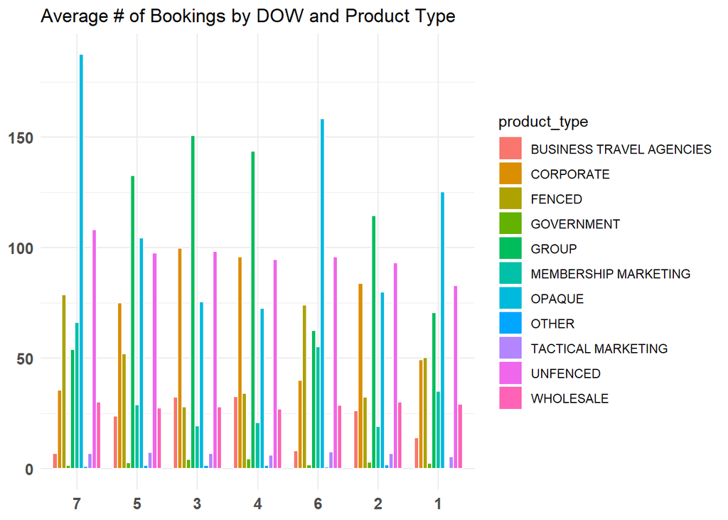

```r
#bookings by day of week and product type

h2_train %>%
  select(day_of_week, product_type, OTB) %>%
  group_by(day_of_week, product_type) %>%
  summarise(avg_bookings = mean(OTB)) %>%
  ggplot(aes(x = reorder(day_of_week, -avg_bookings), y = avg_bookings, fill = product_type)) +
           geom_bar(stat = "identity", width = .8, color = "white", position = "dodge") +
           theme_minimal() +
           theme(axis.title = element_blank(),
                axis.line.y = element_blank(),
                axis.ticks.y = element_blank(),
                axis.text.y = element_text(size = 11, face = "bold"),
                axis.text.x = element_text(size = 11, face = "bold")) +
           ggtitle("Average # of Bookings by DOW and Product Type")
```

Again, this hotel is very different from ATL. Opaque has a lot more bookings, especially on fridays and saturdays. Other, government, and tactial marketing are very small categories and should be grouped with other product types. It seems like this hotel houses a lot of business since corporate and group are so high and they dont have as many staying on fridays and saturday nights.

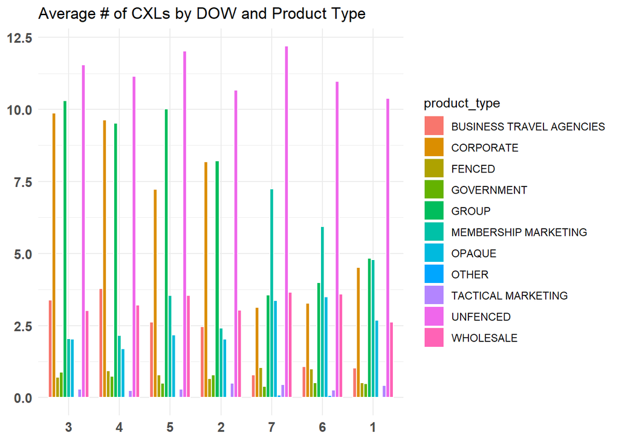

```r
#above by cancellations
h2_train %>%
  select(day_of_week, product_type, OTB_to_be_cxl) %>%
  group_by(day_of_week, product_type) %>%
  summarise(avg_cxl = mean(OTB_to_be_cxl)) %>%
  ggplot(aes(x = reorder(day_of_week, -avg_cxl), y = avg_cxl, fill = product_type)) +
           geom_bar(stat = "identity", width = .8, color = "white", position = "dodge") +
           theme_minimal() +
           theme(axis.title = element_blank(),
                axis.line.y = element_blank(),
                axis.ticks.y = element_blank(),
                axis.text.y = element_text(size = 11, face = "bold"),
                axis.text.x = element_text(size = 11, face = "bold")) +
           ggtitle("Average # of CXLs by DOW and Product Type")
```

Unfenced has by far the highest number of cancellations followed by group then corporate. Look into cancelation curve to create another grouping of product types.

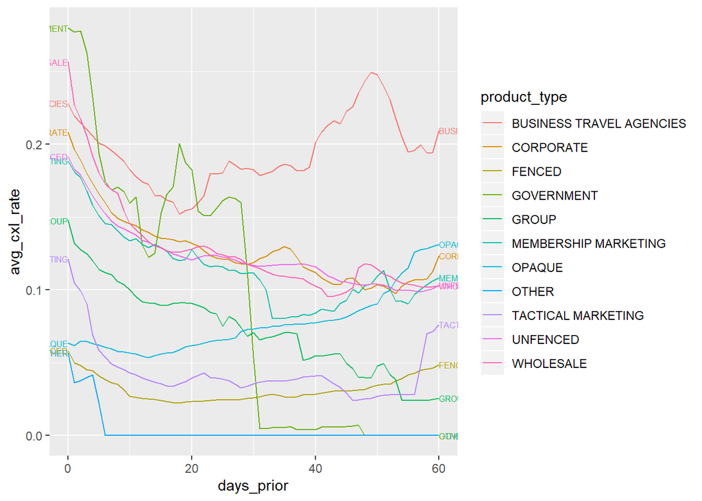

```r
h2_train %>%
  select(product_type, days_prior, cummulative_cxl_bookings, cummulative_gross_bookings) %>%
  filter(cummulative_gross_bookings != 0) %>%
  mutate(cxl_rate = cummulative_cxl_bookings/cummulative_gross_bookings) %>%
  group_by(days_prior, product_type) %>%
  summarise(avg_cxl_rate = mean(cxl_rate)) %>%
  ggplot()+
  geom_line(aes(x=days_prior, y=avg_cxl_rate, color = product_type))+
  geom_dl(aes(label = product_type, x=days_prior, y=avg_cxl_rate, color = product_type), method = list(dl.combine("first.points", "last.points"), cex=0.5))
```

Again, it seems as though truncating the days prior is a good idea for this hotel again. Let’s first look into that.

```r
h2_train %>%
  select(days_prior, daily_cxl_bookings) %>%
  group_by(days_prior) %>%
  summarize(num = sum(daily_cxl_bookings)) %>%
  kable(align = c("c", "c", "c", "c")) %>%
  kable_styling(bootstrap_options = c("striped", "condensed", "bordered")) %>%
  column_spec(1:2, color = "#000000")
```

| days_prior | num |
| --- | --- |
| 0 | 1126 |
| 1 | 686 |
| 2 | 774 |
| 3 | 737 |
| 4 | 675 |
| 5 | 627 |
| 6 | 605 |
| 7 | 503 |
| 8 | 384 |
| 9 | 308 |
| 10 | 271 |
| 11 | 288 |
| 12 | 249 |
| 13 | 272 |
| 14 | 222 |
| 15 | 200 |
| 16 | 177 |
| 17 | 182 |
| 18 | 177 |
| 19 | 201 |
| 20 | 261 |
| 21 | 304 |
| 22 | 325 |
| 23 | 294 |
| 24 | 251 |
| 25 | 179 |
| 26 | 152 |
| 27 | 200 |
| 28 | 182 |
| 29 | 169 |
| 30 | 150 |
| 31 | 102 |
| 32 | 67 |
| 33 | 67 |
| 34 | 59 |
| 35 | 55 |
| 36 | 56 |
| 37 | 57 |
| 38 | 60 |
| 39 | 57 |
| 40 | 67 |
| 41 | 63 |
| 42 | 47 |
| 43 | 43 |
| 44 | 44 |
| 45 | 48 |
| 46 | 50 |
| 47 | 41 |
| 48 | 34 |
| 49 | 34 |
| 50 | 44 |
| 51 | 41 |
| 52 | 40 |
| 53 | 38 |
| 54 | 34 |
| 55 | 38 |
| 56 | 33 |
| 57 | 25 |
| 58 | 15 |
| 59 | 13 |
| 60 | 27 |

- The amount of observations for each days prior goes down significantly after day 31. We will truncate the days prior here.

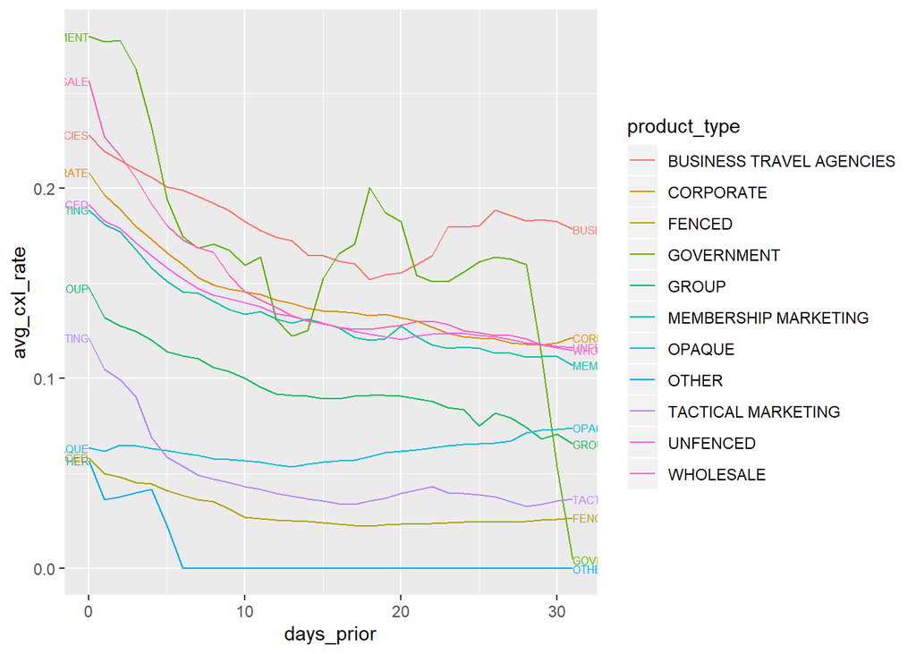

```r
h2_train %>%
  select(product_type, days_prior, cummulative_cxl_bookings, cummulative_gross_bookings) %>%
  filter(cummulative_gross_bookings != 0) %>%
  filter(days_prior <= 31) %>%
  mutate(cxl_rate = cummulative_cxl_bookings/cummulative_gross_bookings) %>%
  group_by(days_prior, product_type) %>%
  summarise(avg_cxl_rate = mean(cxl_rate)) %>%
  ggplot()+
  geom_line(aes(x=days_prior, y=avg_cxl_rate, color = product_type))+
  geom_dl(aes(label = product_type, x=days_prior, y=avg_cxl_rate, color = product_type), method = list(dl.combine("first.points", "last.points"), cex=0.5))
```

A lot of very similar curves. Another grouping of product type is as follows. - Government - wholesale, coporate, membership marketing, group, unfenced - tactical marketing, other - fenced, opaque - business trabel agencies

```r
# number of cancellations in each product type

h2_train %>%
  select(product_type, daily_cxl_bookings) %>%
  group_by(product_type) %>%
  summarize(num = sum(daily_cxl_bookings)) %>%
  kable(align = c("c", "c", "c", "c")) %>%
  kable_styling(bootstrap_options = c("striped", "condensed", "bordered")) %>%
  column_spec(1:2, color = "#000000")
```

| product_type | num |
| --- | --- |
| BUSINESS TRAVEL AGENCIES | 836 |
| CORPORATE | 3113 |
| FENCED | 170 |
| GOVERNMENT | 124 |
| GROUP | 2831 |
| MEMBERSHIP MARKETING | 883 |
| OPAQUE | 761 |
| OTHER | 5 |
| TACTICAL MARKETING | 100 |
| UNFENCED | 3012 |
| WHOLESALE | 695 |

```r
#make this a group
h2_train_2 <- h2_train %>%
      mutate(prod_group_behav = case_when(product_type == 'OPAQUE' ~ 'OP/FENC',
                                         product_type == 'FENCED' ~ 'OP/FENC',
                                         product_type == 'CORPORATE' ~ 'UNF/WHOLE/MEM/GROU/CORP',
                                         product_type == 'BUSINESS TRAVEL AGENCIES' ~ 'BUSINESS TRAVEL AGENCIES',
                                         product_type == 'GROUP' ~ 'UNF/WHOLE/MEM/GROU/CORP',
                                         product_type == 'TACTICAL MARKETING' ~ 'OTH/TACT',
                                         product_type == 'MEMBERSHIP MARKETING' ~ 'UNF/WHOLE/MEM/GROU/CORP',
                                         product_type == 'OTHER' ~ 'OTH/TACT',
                                         product_type == 'UNFENCED' ~ 'UNF/WHOLE/MEM/GROU/CORP',
                                         product_type == 'GOVERNMENT' ~ 'GOVERNMENT',
                                         product_type == 'WHOLESALE' ~ 'UNF/WHOLE/MEM/GROU/CORP'))

#truncate days prior to 32

h2_train_2 <- h2_train_2 %>%
            filter(days_prior <= 31)
```

```r
#make this a group
h2_train_3 <- h2_train %>%
      mutate(prod_group_cxl_rate = case_when(product_type == 'OPAQUE' ~ 'OP/FENC',
                                         product_type == 'FENCED' ~ 'OP/FENC',
                                         product_type == 'CORPORATE' ~ 'UNF/WHOLE/MEM/GROU/CORP',
                                         product_type == 'BUSINESS TRAVEL AGENCIES' ~ 'BUSINESS TRAVEL AGENCIES',
                                         product_type == 'GROUP' ~ 'UNF/WHOLE/MEM/GROU/CORP',
                                         product_type == 'TACTICAL MARKETING' ~ 'OTH/TACT',
                                         product_type == 'MEMBERSHIP MARKETING' ~ 'UNF/WHOLE/MEM/GROU/CORP',
                                         product_type == 'OTHER' ~ 'OTH/TACT',
                                         product_type == 'UNFENCED' ~ 'UNF/WHOLE/MEM/GROU/CORP',
                                         product_type == 'GOVERNMENT' ~ 'GOVERNMENT',
                                         product_type == 'WHOLESALE' ~ 'UNF/WHOLE/MEM/GROU/CORP'))

#truncate days prior to 32

h2_train_3 <- h2_train_3 %>%
            filter(days_prior <= 31)
```

##**Further Analysis**

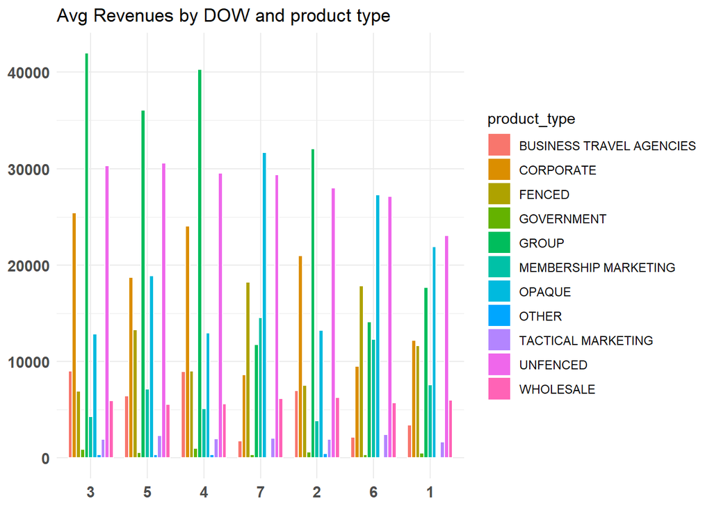

```r
#revenue by day of week

h2_train %>%
  select(day_of_week, product_type, OTB_rev) %>%
  group_by(day_of_week, product_type) %>%
  summarise(avg_rev = mean(OTB_rev)) %>%
  ggplot(aes(x = reorder(day_of_week, -avg_rev), y = avg_rev, fill = product_type)) +
           geom_bar(stat = "identity", width = .8, color = "white", position = "dodge") +
           theme_minimal() +
           theme(axis.title = element_blank(),
                axis.line.y = element_blank(),
                axis.ticks.y = element_blank(),
                axis.text.y = element_text(size = 11, face = "bold"),
                axis.text.x = element_text(size = 11, face = "bold")) +
           ggtitle("Avg Revenues by DOW and product type")
```

Group is very low on friday, saturday, and sunday but hotel does a good job by supplemeniting this with opaque. It would be interesting to see this price average.

```r
#look into days of week  with revenue and pricing

h2_train %>%
  select(OTB, OTB_to_be_cxl, OTB_rev, day_of_week) %>%
  group_by(day_of_week) %>%
  summarise(avg_bookings = mean(OTB),
            avg_cancels = mean(OTB_to_be_cxl),
            avg_otb_rev = mean(OTB_rev),
            avg_price = mean(OTB_rev)/ mean(OTB)) %>%
  arrange(desc(avg_otb_rev)) %>%
  kable(align = c("c", "c", "c", "c")) %>%
  kable_styling(bootstrap_options = c("striped", "condensed", "bordered")) %>%
  column_spec(1:4, color = "#000000")
```

| day_of_week | avg_bookings | avg_cancels | avg_otb_rev | avg_price |
| --- | --- | --- | --- | --- |
| 3 | 50.58408 | 4.080953 | 12985.260 | 256.7065 |
| 5 | 51.29098 | 3.952186 | 12946.366 | 252.4102 |
| 4 | 49.43215 | 3.987401 | 12861.209 | 260.1790 |
| 2 | 46.51217 | 3.684038 | 11539.837 | 248.1036 |
| 7 | 53.46433 | 3.324681 | 11522.018 | 215.5085 |
| 6 | 48.95563 | 3.130847 | 10909.772 | 222.8502 |
| 1 | 43.48767 | 3.007507 | 9868.244 | 226.9205 |

Average prices are relatively the same for all days of week. Is this different by product type?

```r
h2_train %>%
  select(OTB, OTB_to_be_cxl, OTB_rev, day_of_week, product_type) %>%
  group_by(day_of_week, product_type) %>%
  summarise(avg_bookings = mean(OTB),
            avg_cancels = mean(OTB_to_be_cxl),
            avg_otb_rev = mean(OTB_rev),
            avg_price = mean(OTB_rev)/ mean(OTB)) %>%
  arrange(desc(avg_price)) %>%
  kable(align = c("c", "c", "c", "c")) %>%
  kable_styling(bootstrap_options = c("striped", "condensed", "bordered")) %>%
  column_spec(1:6, color = "#000000")
```

| day_of_week | product_type | avg_bookings | avg_cancels | avg_otb_rev | avg_price |
| --- | --- | --- | --- | --- | --- |
| 4 | TACTICAL MARKETING | 6.1770492 | 0.2426230 | 2014.0609672 | 326.055518 |
| 5 | UNFENCED | 97.7393443 | 12.0245902 | 30583.8329836 | 312.912197 |
| 4 | UNFENCED | 94.6672131 | 11.1409836 | 29561.2157869 | 312.264561 |
| 6 | TACTICAL MARKETING | 7.8016393 | 0.2639344 | 2431.1532951 | 311.620826 |
| 5 | TACTICAL MARKETING | 7.5295082 | 0.2967213 | 2327.8180164 | 309.159371 |
| 3 | UNFENCED | 98.2841530 | 11.5464481 | 30291.5309836 | 308.203612 |
| 2 | UNFENCED | 93.1511840 | 10.6684882 | 28014.1530965 | 300.738562 |
| 1 | TACTICAL MARKETING | 5.6245902 | 0.4196721 | 1686.3205738 | 299.812168 |
| 7 | TACTICAL MARKETING | 6.9754098 | 0.4573770 | 2036.4246393 | 291.943368 |
| 6 | UNFENCED | 95.9393443 | 10.9688525 | 27140.7080000 | 282.894450 |
| 4 | GROUP | 143.6508197 | 9.5163934 | 40310.9712459 | 280.617760 |
| 3 | TACTICAL MARKETING | 7.0255009 | 0.2950820 | 1971.2732240 | 280.588281 |
| 2 | GROUP | 114.6666667 | 8.2167577 | 32070.3438069 | 279.683231 |
| 3 | BUSINESS TRAVEL AGENCIES | 32.4153005 | 3.3843352 | 9027.6758288 | 278.500451 |
| 3 | GROUP | 150.9071038 | 10.3023679 | 41989.9662842 | 278.250428 |
| 1 | UNFENCED | 83.0295082 | 10.3803279 | 23084.8603607 | 278.032002 |
| 2 | TACTICAL MARKETING | 7.0746812 | 0.5063752 | 1950.3907104 | 275.686020 |
| 4 | BUSINESS TRAVEL AGENCIES | 32.6967213 | 3.7885246 | 8973.7702787 | 274.454744 |
| 5 | GROUP | 132.6409836 | 10.0114754 | 36041.4691475 | 271.721968 |
| 7 | UNFENCED | 108.2672131 | 12.2000000 | 29386.1290492 | 271.422236 |
| 5 | BUSINESS TRAVEL AGENCIES | 23.8754098 | 2.6180328 | 6425.1812623 | 269.112920 |
| 2 | BUSINESS TRAVEL AGENCIES | 26.3661202 | 2.4571949 | 6995.1206922 | 265.307168 |
| 4 | FENCED | 34.2327869 | 0.9262295 | 9042.5262787 | 264.148119 |
| 6 | BUSINESS TRAVEL AGENCIES | 8.2754098 | 1.0786885 | 2175.0223770 | 262.829566 |
| 5 | FENCED | 52.0049180 | 0.7901639 | 13305.7790984 | 255.856169 |
| 3 | CORPORATE | 99.9635701 | 9.8706740 | 25447.2696721 | 254.565435 |
| 2 | CORPORATE | 83.7978142 | 8.1912568 | 20991.0524226 | 250.496420 |
| 4 | CORPORATE | 95.9508197 | 9.6344262 | 24027.4707049 | 250.414439 |
| 1 | GROUP | 70.7459016 | 4.8344262 | 17664.8892131 | 249.694877 |
| 5 | CORPORATE | 75.1475410 | 7.2295082 | 18724.8334754 | 249.174268 |
| 7 | BUSINESS TRAVEL AGENCIES | 7.0688525 | 0.7868852 | 1753.8852951 | 248.114571 |
| 3 | FENCED | 28.0692168 | 0.7103825 | 6959.5363570 | 247.941951 |
| 1 | CORPORATE | 49.3672131 | 4.5229508 | 12185.5531148 | 246.834941 |
| 5 | MEMBERSHIP MARKETING | 29.0639344 | 3.5475410 | 7142.5569508 | 245.753271 |
| 2 | OTHER | 1.8743169 | 0.0000000 | 457.5449727 | 244.112916 |
| 4 | MEMBERSHIP MARKETING | 20.9540984 | 2.1557377 | 5102.1271311 | 243.490655 |
| 1 | BUSINESS TRAVEL AGENCIES | 14.0803279 | 1.0295082 | 3422.7898525 | 243.090210 |
| 7 | CORPORATE | 35.7590164 | 3.1360656 | 8619.1404918 | 241.034049 |
| 6 | FENCED | 74.2016393 | 0.9967213 | 17851.5518361 | 240.581637 |
| 6 | CORPORATE | 40.0262295 | 3.2672131 | 9521.9861311 | 237.893657 |
| 3 | OTHER | 1.5963115 | 0.0000000 | 373.7534631 | 234.135674 |
| 2 | FENCED | 32.4153005 | 0.6575592 | 7562.8155191 | 233.310054 |
| 7 | FENCED | 78.8393443 | 1.0491803 | 18220.0970164 | 231.104117 |
| 1 | FENCED | 50.4655738 | 0.5196721 | 11642.4526885 | 230.700888 |
| 4 | OTHER | 1.6618852 | 0.0000000 | 378.6555943 | 227.847016 |
| 6 | GROUP | 62.6131148 | 3.9852459 | 14129.0207869 | 225.655932 |
| 5 | OTHER | 1.4863388 | 0.0000000 | 332.2259745 | 223.519681 |
| 6 | MEMBERSHIP MARKETING | 55.1442623 | 5.9442623 | 12304.3787869 | 223.130717 |
| 3 | MEMBERSHIP MARKETING | 19.3934426 | 2.0400729 | 4323.3206193 | 222.926930 |
| 7 | MEMBERSHIP MARKETING | 66.3262295 | 7.2508197 | 14552.1531639 | 219.402690 |
| 4 | GOVERNMENT | 4.5918033 | 0.7459016 | 1006.0142787 | 219.089150 |
| 7 | GROUP | 53.9508197 | 3.5639344 | 11737.2876230 | 217.555316 |
| 1 | MEMBERSHIP MARKETING | 35.0786885 | 4.7819672 | 7597.4975738 | 216.584425 |
| 6 | GOVERNMENT | 1.7322404 | 0.5209472 | 368.6007286 | 212.788433 |
| 5 | GOVERNMENT | 2.7103825 | 0.5045537 | 576.5737705 | 212.727823 |
| 2 | GOVERNMENT | 3.0000000 | 0.7889344 | 632.8750000 | 210.958333 |
| 3 | GOVERNMENT | 4.3811475 | 0.8790984 | 924.1454918 | 210.936857 |
| 3 | WHOLESALE | 28.1693989 | 3.0273224 | 5925.4553734 | 210.350792 |
| 7 | GOVERNMENT | 1.5719490 | 0.3970856 | 329.0036430 | 209.296640 |
| 1 | GOVERNMENT | 2.5348361 | 0.4795082 | 528.5015369 | 208.495352 |
| 4 | WHOLESALE | 26.9475410 | 3.2098361 | 5608.7049180 | 208.134201 |
| 2 | WHOLESALE | 30.3406193 | 3.0346084 | 6254.4881603 | 206.142403 |
| 1 | WHOLESALE | 29.2426230 | 2.6213115 | 5990.3770492 | 204.850880 |
| 7 | WHOLESALE | 30.1721311 | 3.6573770 | 6154.8344262 | 203.990709 |
| 5 | WHOLESALE | 27.5524590 | 3.5377049 | 5578.5491803 | 202.470102 |
| 2 | MEMBERSHIP MARKETING | 19.1894353 | 2.4207650 | 3874.7588707 | 201.921464 |
| 6 | WHOLESALE | 28.8426230 | 3.5868852 | 5753.5688525 | 199.481471 |
| 5 | OPAQUE | 104.6114754 | 2.1737705 | 18872.8177869 | 180.408676 |
| 4 | OPAQUE | 72.6688525 | 1.7032787 | 12951.2682787 | 178.223102 |
| 1 | OPAQUE | 125.2885246 | 2.6868852 | 21888.3230492 | 174.703335 |
| 6 | OPAQUE | 158.3885246 | 3.4918033 | 27277.3749180 | 172.218126 |
| 3 | OPAQUE | 75.6429872 | 2.0255009 | 12862.5281421 | 170.042573 |
| 7 | OPAQUE | 187.5754098 | 3.3737705 | 31678.0120656 | 168.881476 |
| 2 | OPAQUE | 80.0437158 | 2.0327869 | 13228.6789617 | 165.268177 |
| 1 | OTHER | 0.4080146 | 0.0000000 | 4.8234973 | 11.821875 |
| 7 | OTHER | 1.1839709 | 0.0819672 | 4.1427687 | 3.499046 |
| 6 | OTHER | 0.8245902 | 0.0737705 | 0.0082459 | 0.010000 |

```r
#look into days prior with revenue and pricing

h2_train %>%
  select(OTB, OTB_to_be_cxl, OTB_rev, days_prior) %>%
  group_by(days_prior) %>%
  summarise(avg_bookings = mean(OTB),
            avg_cancels = mean(OTB_to_be_cxl),
            avg_otb_rev = mean(OTB_rev),
            avg_price = mean(OTB_rev)/ mean(OTB)) %>%
  arrange(desc(avg_otb_rev)) %>%
  kable(align = c("c", "c", "c", "c")) %>%
  kable_styling(bootstrap_options = c("striped", "condensed", "bordered")) %>%
  column_spec(1:5, color = "#000000")
```

| days_prior | avg_bookings | avg_cancels | avg_otb_rev | avg_price |
| --- | --- | --- | --- | --- |
| 0 | 102.21311 | 0.000000 | 24371.589 | 238.4390 |
| 1 | 100.64344 | 1.306011 | 24049.137 | 238.9538 |
| 2 | 98.29372 | 2.064208 | 23560.462 | 239.6945 |
| 3 | 96.05601 | 2.896175 | 23096.415 | 240.4474 |
| 4 | 93.89071 | 3.602459 | 22613.686 | 240.8512 |
| 5 | 91.73770 | 4.132514 | 22087.209 | 240.7648 |
| 6 | 89.10656 | 4.586066 | 21441.082 | 240.6229 |
| 7 | 86.22678 | 4.923497 | 20722.874 | 240.3299 |
| 8 | 83.40574 | 5.133880 | 20016.588 | 239.9905 |
| 9 | 80.90027 | 5.195355 | 19390.111 | 239.6792 |
| 10 | 78.99863 | 5.267760 | 18927.703 | 239.5953 |
| 11 | 77.22951 | 5.323771 | 18502.866 | 239.5829 |
| 12 | 75.47951 | 5.397541 | 18076.240 | 239.4854 |
| 13 | 73.36202 | 5.351093 | 17541.995 | 239.1155 |
| 14 | 70.75956 | 5.316940 | 16889.117 | 238.6832 |
| 15 | 68.09563 | 5.204918 | 16228.349 | 238.3170 |
| 16 | 65.65027 | 5.091530 | 15628.416 | 238.0556 |
| 17 | 63.43443 | 4.991803 | 15097.111 | 237.9955 |
| 18 | 61.69945 | 4.984973 | 14685.083 | 238.0099 |
| 19 | 59.78415 | 4.946721 | 14232.708 | 238.0682 |
| 20 | 57.66257 | 4.896175 | 13725.930 | 238.0388 |
| 21 | 55.02186 | 4.743169 | 13092.536 | 237.9515 |
| 22 | 52.32240 | 4.591530 | 12440.591 | 237.7680 |
| 23 | 49.85792 | 4.416667 | 11861.529 | 237.9066 |
| 24 | 47.72541 | 4.232240 | 11369.817 | 238.2340 |
| 25 | 46.12842 | 4.133880 | 10994.728 | 238.3504 |
| 26 | 44.73497 | 4.030055 | 10665.882 | 238.4238 |
| 27 | 43.57240 | 3.982240 | 10386.332 | 238.3695 |
| 28 | 42.48361 | 3.980874 | 10128.431 | 238.4080 |
| 29 | 41.25273 | 3.860656 | 9848.500 | 238.7357 |
| 30 | 40.06557 | 3.763661 | 9577.975 | 239.0575 |
| 31 | 38.97814 | 3.681694 | 9336.895 | 239.5418 |
| 32 | 37.93443 | 3.561475 | 9102.583 | 239.9557 |
| 33 | 36.97951 | 3.513661 | 8887.179 | 240.3271 |
| 34 | 36.02869 | 3.469945 | 8668.329 | 240.5952 |
| 35 | 35.09836 | 3.404372 | 8452.482 | 240.8227 |
| 36 | 34.29781 | 3.330601 | 8266.723 | 241.0277 |
| 37 | 33.56831 | 3.278688 | 8098.106 | 241.2426 |
| 38 | 32.93579 | 3.230874 | 7951.608 | 241.4275 |
| 39 | 32.36066 | 3.204918 | 7822.836 | 241.7391 |
| 40 | 31.69672 | 3.148907 | 7663.289 | 241.7692 |
| 41 | 31.04235 | 3.088798 | 7499.650 | 241.5942 |
| 42 | 30.39891 | 3.028688 | 7336.300 | 241.3343 |
| 43 | 29.76776 | 2.980874 | 7187.391 | 241.4488 |
| 44 | 29.24727 | 2.937158 | 7069.494 | 241.7147 |
| 45 | 28.70628 | 2.894809 | 6948.491 | 242.0547 |
| 46 | 28.16393 | 2.859290 | 6831.182 | 242.5507 |
| 47 | 27.59016 | 2.811475 | 6701.441 | 242.8924 |
| 48 | 26.98087 | 2.765027 | 6555.497 | 242.9683 |
| 49 | 26.36612 | 2.724044 | 6401.373 | 242.7878 |
| 50 | 25.77186 | 2.678962 | 6256.183 | 242.7525 |
| 51 | 25.16120 | 2.633880 | 6112.870 | 242.9483 |
| 52 | 24.57650 | 2.575137 | 5973.526 | 243.0584 |
| 53 | 23.99727 | 2.531421 | 5842.772 | 243.4765 |
| 54 | 23.41393 | 2.476776 | 5710.438 | 243.8906 |
| 55 | 22.83333 | 2.413934 | 5572.673 | 244.0587 |
| 56 | 22.18989 | 2.357924 | 5420.087 | 244.2593 |
| 57 | 21.63388 | 2.290984 | 5290.864 | 244.5638 |
| 58 | 21.07924 | 2.236339 | 5166.092 | 245.0797 |
| 59 | 20.57650 | 2.184426 | 5054.846 | 245.6611 |
| 60 | 20.07104 | 2.143443 | 4944.306 | 246.3403 |

Days prior again follows a relatively linear relationship.

```r
#add price to h2_train

h2_train <-  h2_train %>%
  mutate(price = OTB_rev/OTB)
```

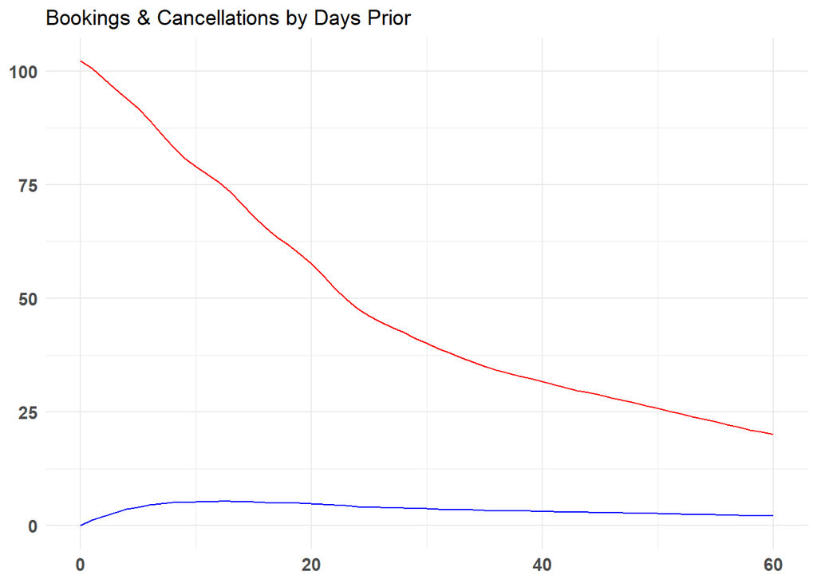

```r
h2_train %>%
  select(days_prior, OTB, OTB_to_be_cxl, OTB_rev) %>%
  group_by(days_prior) %>%
  summarise(avg_net_rev = mean(OTB_rev),
            avg_bookings = mean(OTB),
            avg_cxl = mean(OTB_to_be_cxl)) %>%
  ggplot() +
  geom_line(aes(x = days_prior, y = avg_bookings), color = "red") +
  geom_line(aes(x = days_prior, y = avg_cxl), color = "blue") +
           theme_minimal() +
           theme(axis.title = element_blank(),
                axis.line.y = element_blank(),
                axis.ticks.y = element_blank(),
                axis.text.y = element_text(size = 11, face = "bold"),
                axis.text.x = element_text(size = 11, face = "bold")) +
           ggtitle("Bookings & Cancellations by Days Prior")
```

This has a very similar curve to it that Hotel 1 has.

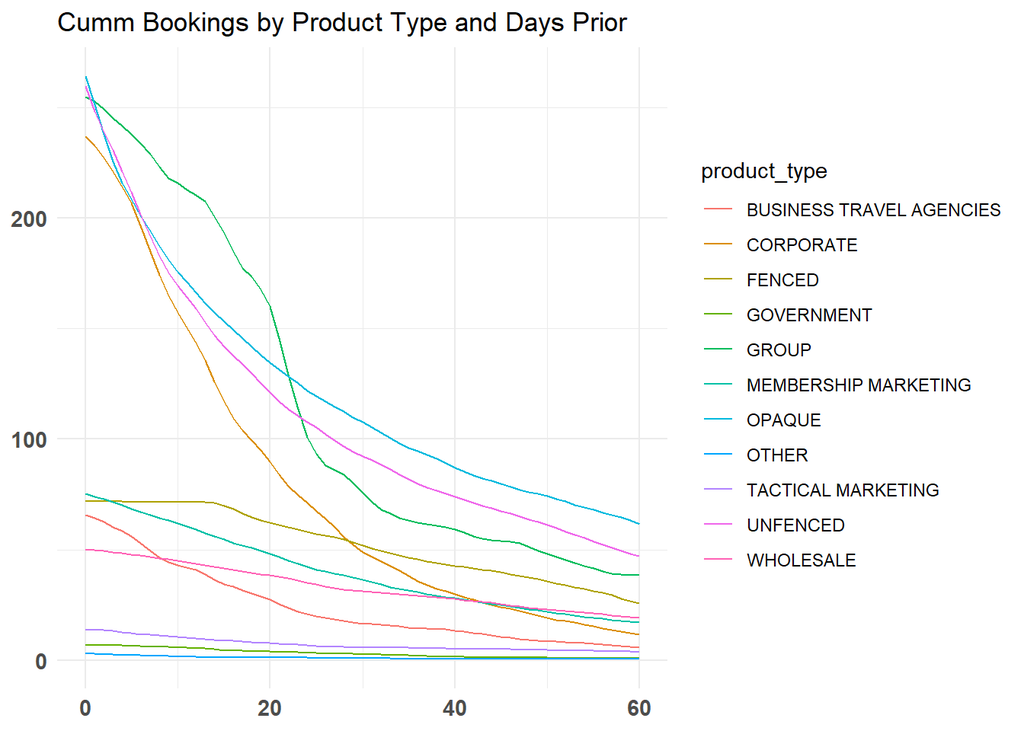

```r
h2_train %>%
  select(days_prior, cummulative_gross_bookings, product_type) %>%
  group_by(days_prior, product_type) %>%
  summarise(avg_bookings = mean(cummulative_gross_bookings)) %>%
  ggplot() +
  geom_line(aes(x = days_prior, y = avg_bookings,  color = product_type)) +
           theme_minimal() +
           theme(axis.title = element_blank(),
                axis.line.y = element_blank(),
                axis.ticks.y = element_blank(),
                axis.text.y = element_text(size = 11, face = "bold"),
                axis.text.x = element_text(size = 11, face = "bold")) +
           ggtitle("Cumm Bookings by Product Type and Days Prior")
```

While some of the groups show an inverse relationship with cummulative bookings and days prior, many show a very steady cummulative bookings. This means that there are not many last minute bookings.

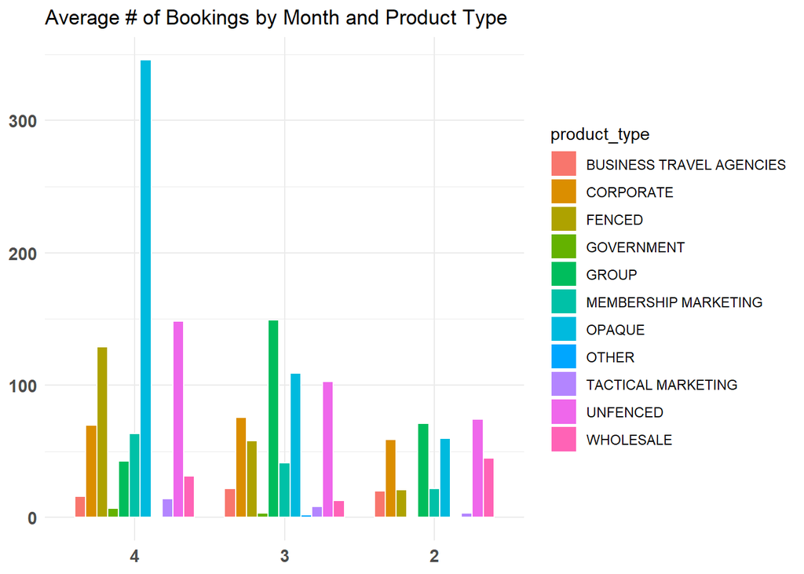

```r
#How does month affect bookings and cancellations
h2_train$month = month(h2_train$stay_dt)

h2_train %>%
  select(month, product_type, OTB) %>%
  group_by(month, product_type) %>%
  summarise(avg_bookings = mean(OTB)) %>%
  ggplot(aes(x = reorder(month, -avg_bookings), y = avg_bookings, fill = product_type)) +
           geom_bar(stat = "identity", width = .8, color = "white", position = "dodge") +
           theme_minimal() +
           theme(axis.title = element_blank(),
                axis.line.y = element_blank(),
                axis.ticks.y = element_blank(),
                axis.text.y = element_text(size = 11, face = "bold"),
                axis.text.x = element_text(size = 11, face = "bold")) +
           ggtitle("Average # of Bookings by Month and Product Type")
```

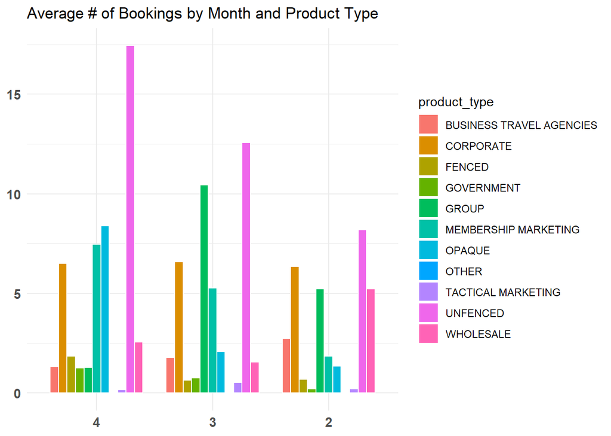

```r
h2_train %>%
  select(month, product_type, OTB_to_be_cxl) %>%
  group_by(month, product_type) %>%
  summarise(avg_bookings = mean(OTB_to_be_cxl)) %>%
  ggplot(aes(x = reorder(month, -avg_bookings), y = avg_bookings, fill = product_type)) +
           geom_bar(stat = "identity", width = .8, color = "white", position = "dodge") +
           theme_minimal() +
           theme(axis.title = element_blank(),
                axis.line.y = element_blank(),
                axis.ticks.y = element_blank(),
                axis.text.y = element_text(size = 11, face = "bold"),
                axis.text.x = element_text(size = 11, face = "bold")) +
           ggtitle("Average # of Bookings by Month and Product Type")
```

This is very different from hotel 1. April actually has the most stay dates while february has the least. However, this is not as steep of a decline as seen in hotel 1.

##**Outliers**

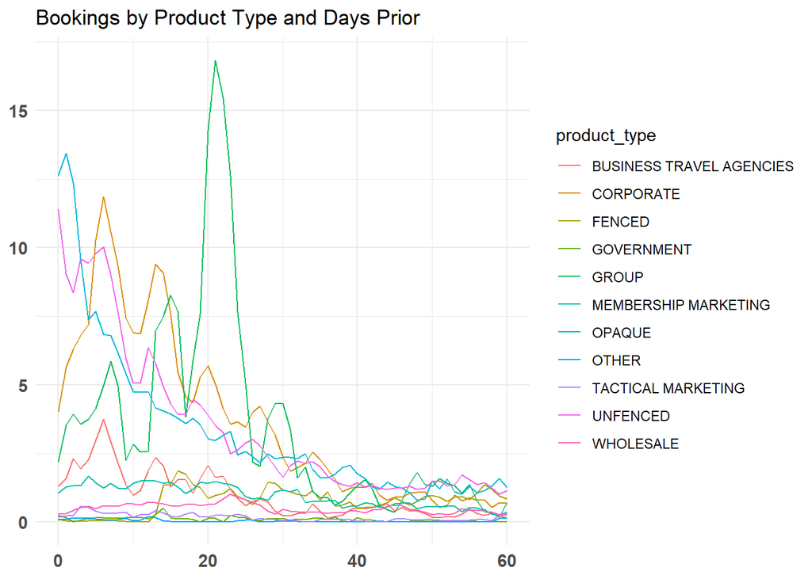

```r
h2_train %>%
  select(days_prior, daily_gross_bookings, product_type) %>%
  group_by(days_prior, product_type) %>%
  summarise(avg_bookings = mean(daily_gross_bookings)) %>%
  ggplot() +
  geom_line(aes(x = days_prior, y = avg_bookings,  color = product_type)) +
           theme_minimal() +
           theme(axis.title = element_blank(),
                axis.line.y = element_blank(),
                axis.ticks.y = element_blank(),
                axis.text.y = element_text(size = 11, face = "bold"),
                axis.text.x = element_text(size = 11, face = "bold")) +
           ggtitle("Bookings by Product Type and Days Prior")
```

There is a huge bump in group about 21 days out, should this be included?

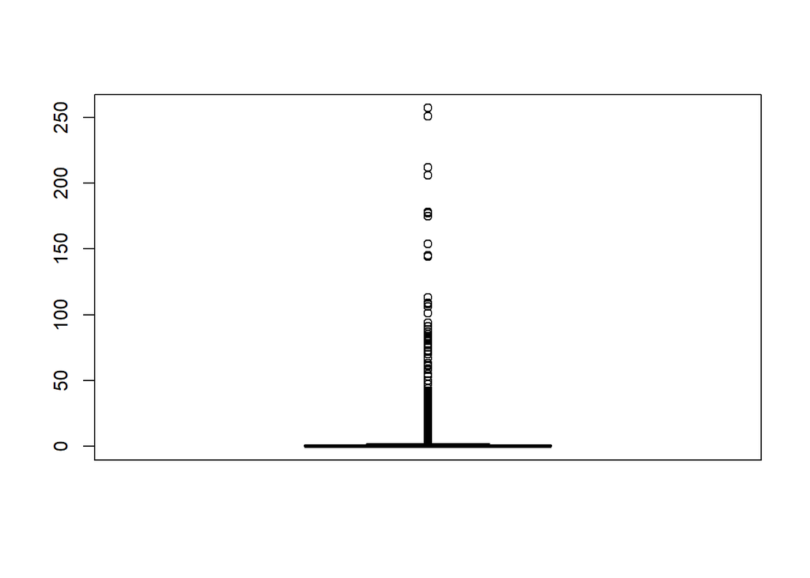

```r
#looking into outliers
group_outlier <- h2_train %>%
                filter(product_type == 'GROUP')

group_outlier <- boxplot(group_outlier$daily_gross_bookings)$out
```